# In 2009, we completed this project as part of our Post Graduate program, and it's fascinating to see how the mobile industry has undergone significant advancements since that time.

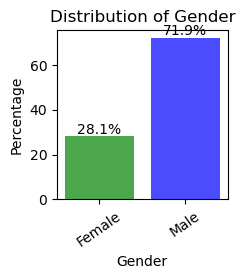

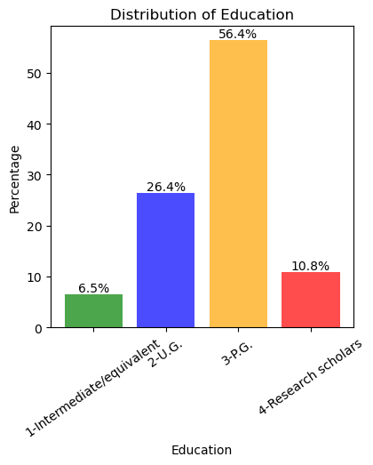

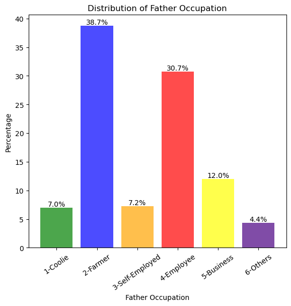

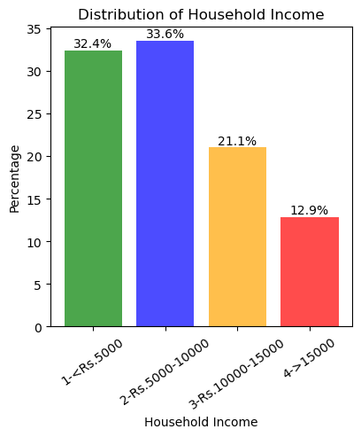

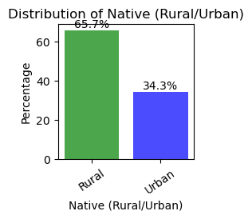

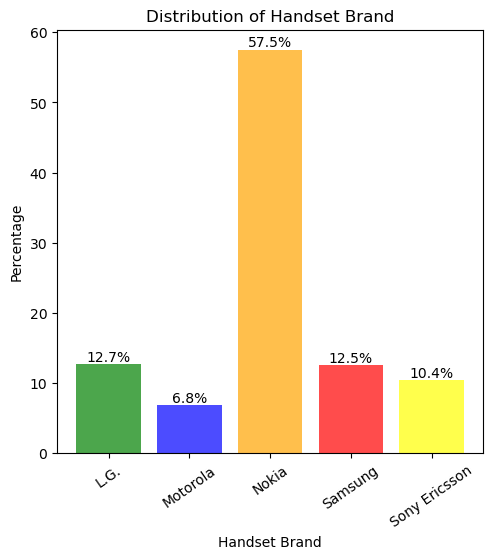

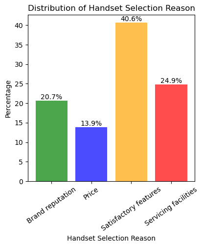

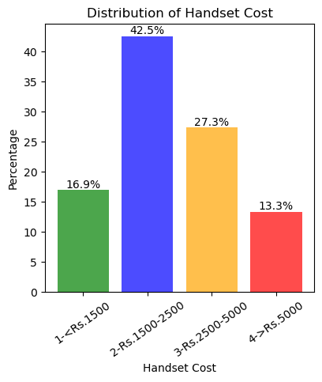

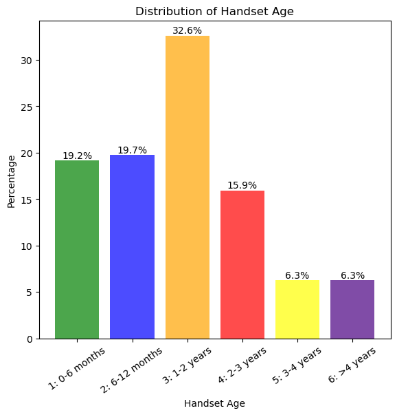

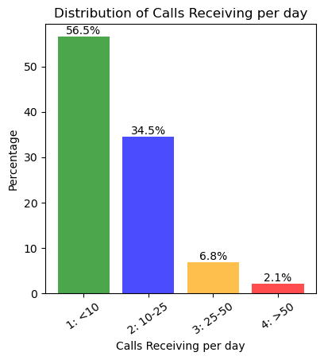

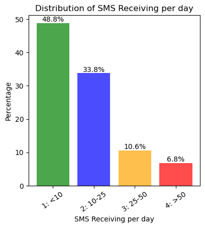

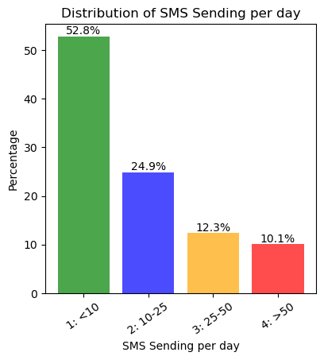

[3 more figures not shown]

```python
# Assuming 'data2' is your DataFrame
columns_of_interest = ['Gender', 'Education', 'Father Occupation',
                        'Household Income', 'Native (Rural/Urban)','Handset Brand',
                        'Handset Selection Reason', 'Handset Cost', 'Handset Age',
                        'Calls Receiving per day', 'SMS Receiving per day',
                        'SMS Sending per day', 'Monthly Mobile Expenditure',
                        'Current Service Provider', 'Current Service Provider Age',]

for column in columns_of_interest:
    # Drop NaN values and group by the specified column
    data2[column] = data2[column].astype('category')
    grouped_data = data2.dropna(subset=[column]).groupby(column)

    # Create a DataFrame with counts and percentages
    data_grouped = grouped_data.size().to_frame('Count').reset_index()
    data_grouped['Percentage'] = data_grouped['Count'] / data_grouped['Count'].sum() * 100

    # Sort the DataFrame by the column of interest
    data_grouped = data_grouped.sort_values(by=column, ascending=True)

    # Calculate the number of categories
    num_categories = len(data_grouped)

    # Adjust the figure size based on the number of categories
    fig_size = (min(8, num_categories * 1.1), min(6, num_categories*1.1))  # Minimum figure size of 8 inches

    # Plot the bar chart
    plt.figure(figsize=fig_size)
    colors = ['green', 'blue', 'orange', 'red', 'yellow', 'indigo', 'cyan']

    bars = plt.bar(x=data_grouped[column], height=data_grouped['Percentage'], color=colors, alpha=0.7)

    # Add value labels on each bar
    for bar in bars:
        yval = bar.get_height()
        plt.text(bar.get_x() + bar.get_width() / 2, yval, f'{round(yval, 1)}%', ha='center', va='bottom')

    plt.xticks(range(len(data_grouped)), rotation=35)
    plt.xlabel(column)
    plt.ylabel('Percentage')
    plt.title(f'Distribution of {column}')
    plt.show()
```

# Analysis of Association

## 2.1 Introduction

In this Chapter we make an attempt to describe some of the features of the sample under study. Particularly, we are interested in knowing whether there exists any association be- tween a few selected pairs of classification variables; if an association exists, then to know the strength and direction of the association. The classification variables we come across in our project work are of categorical in nature. Categorical variables are usually classified as being of two basic types: nominal and ordinal. Nominal variables involve categories that have no particular order. Sex, make of hand set, occupation, birth place etc are examples of nominal variables. Categories associated with an ordinal variable have some inherent ordering. Some examples of ordinal variables are income groups, monthly expenditure towards mobile, years of education etc. Statisticians have developed a number of techniques to analyze and explain categorical data. One such technique that examines the relationship between two categorical variables is contingency table analysis. In Section 2, we briefly review contingency tables, statistical measures that detect the association between the classification variables of a con- tingency table, and measures that quantify the association are described. These are then used in the analysis of the contingency tables.

The cross tables analysis is used to answer questions such as:

- Are the levels of cost of the hand-set independent of the levels of parents’ income ?
- Are the levels of monthly expenditure for the mobile independent of the level of the parents income?
- Is the monthly expenditure the same among the male and female students ?
- Is the monthly expenditure among rural and urban students the same?

# 2.2 Contingency Table Analysis

It is a technique that describes two or more variables simultaneously. It results in tables that reflects the joint distributions of two or more variables that have a finite number of categories or distinct values. It is a technique of merging the frequency distributions of two or more variables into a single table. It helps to understand whether one classification variable such as Income relates to another classification variable such as the Handset Cost owned by an individual. In general, the margins of a cross table show the same information as the frequency tables of the individual variables. These tables are also known as contingency tables. Cross tables are widely used because a series of cross tabulations may give good insight of a complex phenomenon than a single multivariate analysis.

In the analysis of cross tables, we are primarily interested in

- testing whether two samples are homogeneous
- testing the significance of association between the classification variables and
- measuring the strength of the association between the classification variables.

# 2.3 Chi-square Test

To test the homogeneity as well as the statistical significance of the observed association in a cross table, we usually use the Chi-square statistic.

# 2.3 Chi-square Test

To test the homogeneity as well as the statistical significance of the observed association in a cross table, we usually use the Chi-square statistic.

## 2.3.1 Test for Independence

The Chi-square statistic is used to determine whether a systematic association exists between two classification variables. We test the null hypothesis,

H0 = There is no association between two classification variables.

Ha = The two variables are associated.

The test is proceeded by computing the expected cell frequencies if no association were present between the variables, given the row and column totals. In an I × J cross-table, the expected frequency of any cell is obtained by the product of the corresponding row and column totals divided by the grand total. Let nI , nJ , and n denoted the number of observations in a row , in a column and in the table respectively. Then the expected frequencies corresponding to a cell is computed as follows:

After computing the expected cell frequencies, they are compared to the observed cell fre- quencies(O). Their discrepancy is quantified by computing

The calculated value of chi square is then compared with the tabulated value for a given d.f (I-1)(J-1) at a specified level of significance alpha ,where I denotes the no.of rows and J denotes the no. of columns.

## 2.3.2 Test for Homogeneity

To apply this test procedure we assume that separate random samples are obtained from each of two or more populations to determine whether the responses related to a single categorical variable are consistent across populations. The Chi-square test is conducted in exactly the same way as in the case of test for independence. The only difference in the analysis is in the statement of the hypotheses and the conclusions made.

The hypotheses are stated as follows:

H0 = The distribution of categorical variable is the same across the populations .

Ha = The distribution of categorical variable differs across the populations .

# 2.4 Measures of Association

If the association between the classification variables is found to be significant, then we want to measure it. These measures are grouped into two categories nominal and ordinal basing on the classification variables involved. If the classification variables are nominal, then the association between them is measured by using statistics such as

1. Phi Correlation Coefficient,
2. Contingency Coefficient,
3. Cramer’s V,
4. Lambda Coefficient.

On the other hand, if the classification variables are ordinal, then we use the measures such as

1. Gamma,
2. Kendall’s Tau-b,
3. Kendall’s Tau-c,
4. Somers’ d.

# 2.5 INCOME × COST

It might be argued that INCOME forms a series of strata, so that it should be considered as a factor. A similar statement can be made with respect to the COST as well. Since INCOME and COST of the mobile were queried simultaneously, we will treat both of them as random. The usual assumptions lead to a multinomial distribution with I×J levels. That is, let Yij denote the count in the (i, j) cell for a sample of size n. Then, the multinomial parameters are pij , which are the probabilities of a randomly selected individual being at level i of the first response and level j of the second response. Under this model there is only one constraint, which can be written in two ways:

The corresponding null hypothesis is that the variables are independent. This means that the probabilities of the joint events in the cells can be written in terms of the marginal probabilities. That is,

This hypothesis is to tested against the alternative hypothesis

The income groups and the costs of the mobile phones are coded as follows:

| Income Groups | Income Group Code |
| --- | --- |
| < 5,000 | 1 |
| 5,000 - 10,000 | 2 |
| 10,000 - 15,000 | 3 |
| > 15,000 | 4 |

| Handset Cost | Handset Cost Code |
| --- | --- |
| < 1,500 | 1 |
| 1,500 - 2,500 | 2 |
| 2,500 - 5,000 | 3 |
| > 5,000 | 4 |

```python
data2.groupby(['Household Income']).size()
```

```
Household Income
1-<Rs.5000          171
2-Rs.5000-10000     177
3-Rs.10000-15000    111
4->15000             68
dtype: int64
```

```python
data2.groupby(['Household Income', 'Handset Cost']).size()
```

```
Household Income  Handset Cost
1-<Rs.5000        1-<Rs.1500        44
                  2-Rs.1500-2500    83
                  3-Rs.2500-5000    36
                  4->Rs.5000         8
2-Rs.5000-10000   1-<Rs.1500        26
                  2-Rs.1500-2500    88
                  3-Rs.2500-5000    47
                  4->Rs.5000        16
3-Rs.10000-15000  1-<Rs.1500        15
                  2-Rs.1500-2500    38
                  3-Rs.2500-5000    38
                  4->Rs.5000        20
4->15000          1-<Rs.1500         4
                  2-Rs.1500-2500    15
                  3-Rs.2500-5000    23
                  4->Rs.5000        26
dtype: int64
```

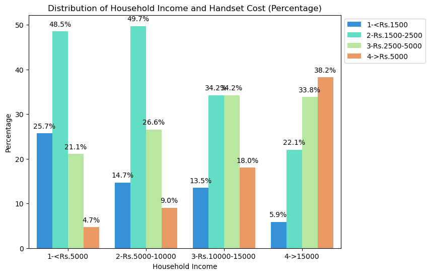

```python
# Assuming 'data2' is your DataFrame
columns_of_interest = ['Household Income', 'Handset Cost']

# Filter the DataFrame for the selected columns
selected_data = data2[columns_of_interest].dropna()

# Calculate the percentages within each category
percentages = selected_data.groupby(['Household Income', 'Handset Cost']).size() / selected_data.groupby(['Household Income']).size() * 100
percentages = percentages.reset_index(name='Percentage')

# Create a grouped bar chart using Seaborn
plt.figure(figsize=(8,6))
ax = sns.barplot(data=percentages, x='Household Income', y='Percentage', hue='Handset Cost', palette='rainbow')

# Add data labels for each bar
for p in ax.patches:
    ax.annotate(f'{p.get_height():.1f}%', (p.get_x() + p.get_width() / 2., p.get_height()),
                ha='center', va='center', xytext=(0, 10), textcoords='offset points')

# Move the legend outside the plot
ax.legend(loc='upper left', bbox_to_anchor=(1, 1))

plt.xlabel('Household Income')
plt.ylabel('Percentage')
plt.title('Distribution of Household Income and Handset Cost (Percentage)')
plt.show()
```

From the above graph we can observe that

- As the Income level increases, the proportion of students using costly handsets increases.
- As the Income level increases, the proportion of students using low-cost handsets decreases.
- In Income groups < 5,000 as well as 5,000−10,000, almost 50% of students are using handsets with a cost in the range of 1,500−2,500.

From the above inferences, it seems that there is some association between Income level and Hand-set cost. We will verify this by constructing a Income × Cost cross-table. Our data set has resulted in the following cross-table for Income versus Cost of the mobile.

```python
#The cross table for Income × Cost has resulted in the following:


# Assuming 'data2' is your DataFrame
columns_of_interest = ['Household Income', 'Handset Cost']

# Filter the DataFrame for the selected columns
selected_data = data2[columns_of_interest].dropna()

# Create a crosstabulation
cross_tab = pd.crosstab(selected_data['Handset Cost'],selected_data['Household Income']
                        , margins=True, margins_name='Total')

# Display the crosstab
print(cross_tab)
cross_tab
```

```
Household Income  1-<Rs.5000  2-Rs.5000-10000  3-Rs.10000-15000  4->15000  \
Handset Cost
1-<Rs.1500                44               26                15         4
2-Rs.1500-2500            83               88                38        15
3-Rs.2500-5000            36               47                38        23
4->Rs.5000                 8               16                20        26
Total                    171              177               111        68

Household Income  Total
Handset Cost
1-<Rs.1500           89
2-Rs.1500-2500      224
3-Rs.2500-5000      144
4->Rs.5000           70
Total               527
```

| Household Income Handset Cost | 1-<Rs.5000 | 2-Rs.5000-10000 | 3-Rs.10000-15000 | 4->15000 | Total |
| --- | --- | --- | --- | --- | --- |
| 1-<Rs.1500 | 44 | 26 | 15 | 4 | 89 |
| 2-Rs.1500-2500 | 83 | 88 | 38 | 15 | 224 |
| 3-Rs.2500-5000 | 36 | 47 | 38 | 23 | 144 |
| 4->Rs.5000 | 8 | 16 | 20 | 26 | 70 |
| Total | 171 | 177 | 111 | 68 | 527 |

```python
# Assuming 'data2' is your DataFrame
columns_of_interest = ['Household Income', 'Handset Cost']

# Filter the DataFrame for the selected columns
selected_data = data2[columns_of_interest].dropna()

# Create a crosstabulation with observed counts
observed_cross_tab = pd.crosstab(selected_data['Handset Cost'], selected_data['Household Income'], margins=True, margins_name='Total')

# Calculate expected counts using chi-squared test
_, _, _, expected = chi2_contingency(observed_cross_tab)

# Create a DataFrame for expected counts
expected_cross_tab = pd.DataFrame(expected, columns=observed_cross_tab.columns, index=observed_cross_tab.index)

# Display both observed and expected crosstabs
# print("Observed Counts:")
# print(observed_cross_tab)

# print("\nExpected Counts:")
# print(expected_cross_tab)

# Combine observed and expected counts into a single DataFrame
combined_cross_tab = pd.concat([observed_cross_tab, expected_cross_tab], keys=['Observed', 'Expected'], axis=0)

# Display the combined crosstab
#print(combined_cross_tab)

combined_cross_tab
```

|  | Household Income Handset Cost | 1-<Rs.5000 | 2-Rs.5000-10000 | 3-Rs.10000-15000 | 4->15000 | Total |
| --- | --- | --- | --- | --- | --- | --- |
| Observed | 1-<Rs.1500 | 44.000000 | 26.000000 | 15.000000 | 4.000000 | 89.0 |
|  | 2-Rs.1500-2500 | 83.000000 | 88.000000 | 38.000000 | 15.000000 | 224.0 |
|  | 3-Rs.2500-5000 | 36.000000 | 47.000000 | 38.000000 | 23.000000 | 144.0 |
|  | 4->Rs.5000 | 8.000000 | 16.000000 | 20.000000 | 26.000000 | 70.0 |
|  | Total | 171.000000 | 177.000000 | 111.000000 | 68.000000 | 527.0 |
| Expected | 1-<Rs.1500 | 28.878558 | 29.891841 | 18.745731 | 11.483871 | 89.0 |
|  | 2-Rs.1500-2500 | 72.683112 | 75.233397 | 47.180266 | 28.903226 | 224.0 |
|  | 3-Rs.2500-5000 | 46.724858 | 48.364326 | 30.330171 | 18.580645 | 144.0 |
|  | 4->Rs.5000 | 22.713472 | 23.510436 | 14.743833 | 9.032258 | 70.0 |
|  | Total | 171.000000 | 177.000000 | 111.000000 | 68.000000 | 527.0 |

```python
# Assuming 'data2' is your DataFrame
columns_of_interest = ['Household Income', 'Handset Cost']

# Filter the DataFrame for the selected columns
selected_data = data2[columns_of_interest].dropna()

# Create a crosstabulation with observed counts
observed_cross_tab = pd.crosstab(selected_data['Handset Cost'], selected_data['Household Income'], margins=True, margins_name='Total')

# Calculate expected counts using chi-squared test
_, _, _, expected = chi2_contingency(observed_cross_tab)

# Create DataFrames for observed and expected counts
observed_df = pd.DataFrame(observed_cross_tab.values, columns=observed_cross_tab.columns, index=observed_cross_tab.index)
expected_df = pd.DataFrame(expected, columns=observed_cross_tab.columns, index=observed_cross_tab.index)

# Calculate percentages within each income group
observed_percentages = observed_df.div(observed_df.loc['Total']) * 100
#expected_percentages = expected_df.div(expected_df.loc['Total']) * 100

# Combine observed and expected counts and percentages into a single DataFrame
combined_cross_tab = pd.concat([observed_df, expected_df, observed_percentages], axis=0,
                               keys=['Observed', 'Expected',  'Observed (%)'])

# Display the combined crosstab with percentages
#print(combined_cross_tab)
combined_cross_tab
```

|  | Household Income Handset Cost | 1-<Rs.5000 | 2-Rs.5000-10000 | 3-Rs.10000-15000 | 4->15000 | Total |
| --- | --- | --- | --- | --- | --- | --- |
| Observed | 1-<Rs.1500 | 44.000000 | 26.000000 | 15.000000 | 4.000000 | 89.000000 |
|  | 2-Rs.1500-2500 | 83.000000 | 88.000000 | 38.000000 | 15.000000 | 224.000000 |
|  | 3-Rs.2500-5000 | 36.000000 | 47.000000 | 38.000000 | 23.000000 | 144.000000 |
|  | 4->Rs.5000 | 8.000000 | 16.000000 | 20.000000 | 26.000000 | 70.000000 |
|  | Total | 171.000000 | 177.000000 | 111.000000 | 68.000000 | 527.000000 |
| Expected | 1-<Rs.1500 | 28.878558 | 29.891841 | 18.745731 | 11.483871 | 89.000000 |
|  | 2-Rs.1500-2500 | 72.683112 | 75.233397 | 47.180266 | 28.903226 | 224.000000 |
|  | 3-Rs.2500-5000 | 46.724858 | 48.364326 | 30.330171 | 18.580645 | 144.000000 |
|  | 4->Rs.5000 | 22.713472 | 23.510436 | 14.743833 | 9.032258 | 70.000000 |
|  | Total | 171.000000 | 177.000000 | 111.000000 | 68.000000 | 527.000000 |
| Observed (%) | 1-<Rs.1500 | 25.730994 | 14.689266 | 13.513514 | 5.882353 | 16.888046 |
|  | 2-Rs.1500-2500 | 48.538012 | 49.717514 | 34.234234 | 22.058824 | 42.504744 |
|  | 3-Rs.2500-5000 | 21.052632 | 26.553672 | 34.234234 | 33.823529 | 27.324478 |
|  | 4->Rs.5000 | 4.678363 | 9.039548 | 18.018018 | 38.235294 | 13.282732 |
|  | Total | 100.000000 | 100.000000 | 100.000000 | 100.000000 | 100.000000 |

##### Clearly, there are discrepancies between the actual frequencies and the expected frequencies. Are these differences statistically significant? To know this, Pearson’s Chi-square test is conducted, and the results are presented in the following table:

```python
# Assuming 'data2' is your DataFrame
columns_of_interest = ['Household Income', 'Handset Cost']

# Filter the DataFrame for the selected columns
selected_data = data2[columns_of_interest].dropna()

# Create a crosstabulation with observed counts
observed_cross_tab = pd.crosstab(selected_data['Handset Cost'], selected_data['Household Income'])

# Perform chi-squared test
chi2_stat, p_value, dof, expected = chi2_contingency(observed_cross_tab)

# Calculate minimum expected count
min_expected_count = np.min(expected)

# Count cells with expected count less than 5
cells_with_low_expected_count = np.sum(expected < 5)
cells_with_low_expected_count_pct=cells_with_low_expected_count/(observed_cross_tab.size)

# Display chi-square test results in a table
table = [
    ["Pearson Chi-Square", chi2_stat],
    ["Likelihood Ratio", chi2_contingency(observed_cross_tab, lambda_='log-likelihood')[0]],
    ["Linear-by-Linear Association", chi2_contingency(observed_cross_tab, correction=True)[0]],
    ["N of Valid Cases", selected_data.shape[0]],
    ["df", dof],
    ["Asymp. Sig (2-sided) - P-value", p_value],
    ["Minimum Expected Count", min_expected_count],
    [f"{cells_with_low_expected_count} cells ({cells_with_low_expected_count_pct}%) have expected count less than 5."]
]

print("\nChi-Square Test Results:")
print(tabulate(table, headers=[ "Value"]))
```

```
Chi-Square Test Results:
                                                         Value
-----------------------------------------------  -------------
Pearson Chi-Square                                77.3253
Likelihood Ratio                                  71.8236
Linear-by-Linear Association                      77.3253
N of Valid Cases                                 527
df                                                 9
Asymp. Sig (2-sided) - P-value                     5.48211e-13
Minimum Expected Count                             9.03226
0 cells (0.0%) have expected count less than 5.
```

From the table we note that the **p − value < 0.05** and hence the assumption of independence between the classification variables is rejected. Thus, there is some dependence between the factor levels of Income and Cost. Our next problem is to find out the strength of the association between the factor levels of Income and Cost of the mobile.

To measure the strength of association between categorical variables, SPSS offers several measures of association. These measures are grouped into two categories namely nominal and ordinal. Note that both the classification variables in the above crosstable are ordinal in nature. Thus, it is appropriate to use ordinal measure of association to assess the strength. Somers’ d is one such measure. Somers’ d is an **ordinal directional measure** that indicates the significance, strength and direction of the relationship between the row and column variables of a cross tabulation. A low significance value (typically less than 0.05) indicates that there is a relationship between the two variables. The value of the statistic can range from -1 to 1. Negative values indicate a negative relationship, and positive values indicate a positive relationship. Somers’ d is appropriate when both variables are ordinal, categorical variables.

```python
from scipy.stats import somersd

# Assuming 'data2' is your DataFrame
columns_of_interest = ['Household Income', 'Handset Cost']

# Filter the DataFrame for the selected columns
selected_data = data2[columns_of_interest].dropna()

# Calculate Somers' d in both directions
result1 = somersd(selected_data['Handset Cost'], selected_data['Household Income'])
result2 = somersd(selected_data['Household Income'], selected_data['Handset Cost'])

# Access the Somers' d statistic from the result objects
somersd_statistic1 = result1.statistic
somersd_statistic2 = result2.statistic

# Calculate the average of symmetric Somers' D
symmetric_somersd = (somersd_statistic1 + somersd_statistic2) / 2

# Calculate the standard error of Somers' D
n = len(selected_data)
se_d1 = np.sqrt(2 * (1 - somersd_statistic1 ** 2) / (n * (n - 1)))
se_d2 = np.sqrt(2 * (1 - somersd_statistic2 ** 2) / (n * (n - 1)))
se_ds = np.sqrt(2 * (1 - symmetric_somersd ** 2) / (n * (n - 1)))

# Calculate the asymptotic standard error (ASE) without assuming the null hypothesis
ase_d1 = np.sqrt(2 * (1 - somersd_statistic1 ** 2) / n)
ase_d2 = np.sqrt(2 * (1 - somersd_statistic2 ** 2) / n)
ase_ds = np.sqrt(2 * (1 - symmetric_somersd ** 2) / n)


# Create a list of dictionaries for the table with rounded values
table = [
    {"": "Symmetric Somers' D:", "Value": round(symmetric_somersd, 3), "P-value": None, "Standard Error": round(se_ds, 3), "Asymptotic Standard Error": round(ase_ds, 3)},
    {"": "Handset Cost Dependent Somers' D:", "Value": round(somersd_statistic2, 3), "P-value": round(result2.pvalue, 3), "Standard Error": round(se_d2, 3), "Asymptotic Standard Error": round(ase_d2, 3)},
    {"": "Income Dependent Somers' D:", "Value": round(somersd_statistic1, 3), "P-value": round(result1.pvalue, 3), "Standard Error": round(se_d1, 3), "Asymptotic Standard Error": round(ase_d1, 3)},


]

# Print the table using the tabulate library
print("\nSomers' d Test Results:")
print(tabulate(table, headers="keys", tablefmt="pretty"))
```

```
Somers' d Test Results:
+-----------------------------------+-------+---------+----------------+---------------------------+
|                                   | Value | P-value | Standard Error | Asymptotic Standard Error |
+-----------------------------------+-------+---------+----------------+---------------------------+
|       Symmetric Somers' D:        | 0.283 |         |     0.003      |           0.059           |
| Handset Cost Dependent Somers' D: | 0.279 |   0.0   |     0.003      |           0.059           |
|    Income Dependent Somers' D:    | 0.288 |   0.0   |     0.003      |           0.059           |
+-----------------------------------+-------+---------+----------------+---------------------------+
```

# 2.5 INCOME × EXPENDITURE

It might be argued that INCOME forms a series of strata, so that it should be considered as a factor. A similar statement can be made with respect to the COST as well. Since INCOME and EXPENDITURE of the mobile were queried simultaneously, we will treat both of them as random. The usual assumptions lead to a multinomial distribution with I×J levels. That is, let Yij denote the count in the (i, j) cell for a sample of size n. Then, the multinomial parameters are pij , which are the probabilities of a randomly selected individual being at level i of the first response and level j of the second response. Under this model there is only one constraint, which can be written in two ways:

The corresponding null hypothesis is that the variables are independent. This means that the probabilities of the joint events in the cells can be written in terms of the marginal probabilities. That is,

This hypothesis is to tested against the alternative hypothesis

The income groups and the expenditures of the mobile phones are coded as follows:

| Income Groups | Code |
| --- | --- |
| < 5,000 | 1 |
| 5,000 - 10,000 | 2 |
| 10,000 - 15,000 | 3 |
| > 15,000 | 4 |

| Monthly Expenditure | Code |
| --- | --- |
| < 300 | 1 |
| 300 - 500 | 2 |
| 500 - 1,000 | 3 |
| > 1,000 | 4 |

```python
data2.groupby(['Household Income']).size()
```

```
Household Income
1-<Rs.5000          171
2-Rs.5000-10000     177
3-Rs.10000-15000    111
4->15000             68
dtype: int64
```

```python
data2.groupby(['Household Income', 'Monthly Mobile Expenditure']).size()
```

```
Household Income  Monthly Mobile Expenditure
1-<Rs.5000        1-<Rs.300                     142
                  2-Rs.300-500                   22
                  3-Rs.500-1000                   4
                  4->Rs.1000                      3
2-Rs.5000-10000   1-<Rs.300                     117
                  2-Rs.300-500                   50
                  3-Rs.500-1000                   3
                  4->Rs.1000                      7
3-Rs.10000-15000  1-<Rs.300                      70
                  2-Rs.300-500                   24
                  3-Rs.500-1000                  12
                  4->Rs.1000                      5
4->15000          1-<Rs.300                      42
                  2-Rs.300-500                   17
                  3-Rs.500-1000                   6
                  4->Rs.1000                      3
dtype: int64
```

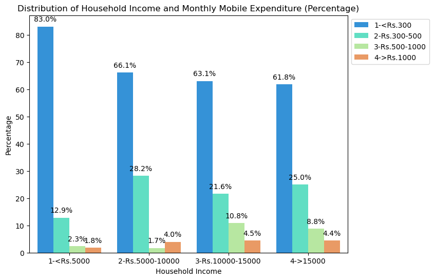

```python
# Assuming 'data2' is your DataFrame
columns_of_interest = ['Household Income', 'Monthly Mobile Expenditure']

# Filter the DataFrame for the selected columns
selected_data = data2[columns_of_interest].dropna()

# Calculate the percentages within each category
percentages = selected_data.groupby(['Household Income', 'Monthly Mobile Expenditure']).size() / selected_data.groupby(['Household Income']).size() * 100
percentages = percentages.reset_index(name='Percentage')

# Create a grouped bar chart using Seaborn
plt.figure(figsize=(8,6))
ax = sns.barplot(data=percentages, x='Household Income', y='Percentage', hue='Monthly Mobile Expenditure', palette='rainbow')

# Add data labels for each bar
for p in ax.patches:
    ax.annotate(f'{p.get_height():.1f}%', (p.get_x() + p.get_width() / 2., p.get_height()),
                ha='center', va='center', xytext=(0, 10), textcoords='offset points')

# Move the legend outside the plot
ax.legend(loc='upper left', bbox_to_anchor=(1, 1))

plt.xlabel('Household Income')
plt.ylabel('Percentage')
plt.title('Distribution of Household Income and Monthly Mobile Expenditure (Percentage)')
plt.show()
```

```python
#The cross table for Income × Cost has resulted in the following:


# Assuming 'data2' is your DataFrame
columns_of_interest = ['Household Income', 'Monthly Mobile Expenditure']

# Filter the DataFrame for the selected columns
selected_data = data2[columns_of_interest].dropna()

# Create a crosstabulation
cross_tab = pd.crosstab(selected_data['Monthly Mobile Expenditure'],selected_data['Household Income']
                        , margins=True, margins_name='Total')

# Display the crosstab
print(cross_tab)
cross_tab
```

```
Household Income            1-<Rs.5000  2-Rs.5000-10000  3-Rs.10000-15000  \
Monthly Mobile Expenditure
1-<Rs.300                          142              117                70
2-Rs.300-500                        22               50                24
3-Rs.500-1000                        4                3                12
4->Rs.1000                           3                7                 5
Total                              171              177               111

Household Income            4->15000  Total
Monthly Mobile Expenditure
1-<Rs.300                         42    371
2-Rs.300-500                      17    113
3-Rs.500-1000                      6     25
4->Rs.1000                         3     18
Total                             68    527
```

| Household Income Monthly Mobile Expenditure | 1-<Rs.5000 | 2-Rs.5000-10000 | 3-Rs.10000-15000 | 4->15000 | Total |
| --- | --- | --- | --- | --- | --- |
| 1-<Rs.300 | 142 | 117 | 70 | 42 | 371 |
| 2-Rs.300-500 | 22 | 50 | 24 | 17 | 113 |
| 3-Rs.500-1000 | 4 | 3 | 12 | 6 | 25 |
| 4->Rs.1000 | 3 | 7 | 5 | 3 | 18 |
| Total | 171 | 177 | 111 | 68 | 527 |

```python
# Assuming 'data2' is your DataFrame
columns_of_interest = ['Household Income', 'Monthly Mobile Expenditure']

# Filter the DataFrame for the selected columns
selected_data = data2[columns_of_interest].dropna()

# Create a crosstabulation with observed counts
observed_cross_tab = pd.crosstab(selected_data['Monthly Mobile Expenditure'], selected_data['Household Income'], margins=True, margins_name='Total')

# Calculate expected counts using chi-squared test
_, _, _, expected = chi2_contingency(observed_cross_tab)

# Create a DataFrame for expected counts
expected_cross_tab = pd.DataFrame(expected, columns=observed_cross_tab.columns, index=observed_cross_tab.index)

# Display both observed and expected crosstabs
# print("Observed Counts:")
# print(observed_cross_tab)

# print("\nExpected Counts:")
# print(expected_cross_tab)

# Combine observed and expected counts into a single DataFrame
combined_cross_tab = pd.concat([observed_cross_tab, expected_cross_tab], keys=['Observed', 'Expected'], axis=0)

# Display the combined crosstab
# print(combined_cross_tab)

combined_cross_tab
```

|  | Household Income Monthly Mobile Expenditure | 1-<Rs.5000 | 2-Rs.5000-10000 | 3-Rs.10000-15000 | 4->15000 | Total |
| --- | --- | --- | --- | --- | --- | --- |
| Observed | 1-<Rs.300 | 142.000000 | 117.000000 | 70.000000 | 42.000000 | 371.0 |
|  | 2-Rs.300-500 | 22.000000 | 50.000000 | 24.000000 | 17.000000 | 113.0 |
|  | 3-Rs.500-1000 | 4.000000 | 3.000000 | 12.000000 | 6.000000 | 25.0 |
|  | 4->Rs.1000 | 3.000000 | 7.000000 | 5.000000 | 3.000000 | 18.0 |
|  | Total | 171.000000 | 177.000000 | 111.000000 | 68.000000 | 527.0 |
| Expected | 1-<Rs.300 | 120.381404 | 124.605313 | 78.142315 | 47.870968 | 371.0 |
|  | 2-Rs.300-500 | 36.666034 | 37.952562 | 23.800759 | 14.580645 | 113.0 |
|  | 3-Rs.500-1000 | 8.111954 | 8.396584 | 5.265655 | 3.225806 | 25.0 |
|  | 4->Rs.1000 | 5.840607 | 6.045541 | 3.791271 | 2.322581 | 18.0 |
|  | Total | 171.000000 | 177.000000 | 111.000000 | 68.000000 | 527.0 |

```python
# Assuming 'data2' is your DataFrame
columns_of_interest = ['Household Income', 'Monthly Mobile Expenditure']

# Filter the DataFrame for the selected columns
selected_data = data2[columns_of_interest].dropna()

# Create a crosstabulation with observed counts
observed_cross_tab = pd.crosstab(selected_data['Monthly Mobile Expenditure'], selected_data['Household Income'], margins=True, margins_name='Total')

# Calculate expected counts using chi-squared test
_, _, _, expected = chi2_contingency(observed_cross_tab)

# Create DataFrames for observed and expected counts
observed_df = pd.DataFrame(observed_cross_tab.values, columns=observed_cross_tab.columns, index=observed_cross_tab.index)
expected_df = pd.DataFrame(expected, columns=observed_cross_tab.columns, index=observed_cross_tab.index)

# Calculate percentages within each income group
observed_percentages = observed_df.div(observed_df.loc['Total']) * 100
#expected_percentages = expected_df.div(expected_df.loc['Total']) * 100

# Combine observed and expected counts and percentages into a single DataFrame
combined_cross_tab = pd.concat([observed_df, expected_df, observed_percentages], axis=0,
                               keys=['Observed', 'Expected',  'Observed (%)'])

# Display the combined crosstab with percentages
#print(combined_cross_tab)
combined_cross_tab
```

|  | Household Income Monthly Mobile Expenditure | 1-<Rs.5000 | 2-Rs.5000-10000 | 3-Rs.10000-15000 | 4->15000 | Total |
| --- | --- | --- | --- | --- | --- | --- |
| Observed | 1-<Rs.300 | 142.000000 | 117.000000 | 70.000000 | 42.000000 | 371.000000 |
|  | 2-Rs.300-500 | 22.000000 | 50.000000 | 24.000000 | 17.000000 | 113.000000 |
|  | 3-Rs.500-1000 | 4.000000 | 3.000000 | 12.000000 | 6.000000 | 25.000000 |
|  | 4->Rs.1000 | 3.000000 | 7.000000 | 5.000000 | 3.000000 | 18.000000 |
|  | Total | 171.000000 | 177.000000 | 111.000000 | 68.000000 | 527.000000 |
| Expected | 1-<Rs.300 | 120.381404 | 124.605313 | 78.142315 | 47.870968 | 371.000000 |
|  | 2-Rs.300-500 | 36.666034 | 37.952562 | 23.800759 | 14.580645 | 113.000000 |
|  | 3-Rs.500-1000 | 8.111954 | 8.396584 | 5.265655 | 3.225806 | 25.000000 |
|  | 4->Rs.1000 | 5.840607 | 6.045541 | 3.791271 | 2.322581 | 18.000000 |
|  | Total | 171.000000 | 177.000000 | 111.000000 | 68.000000 | 527.000000 |
| Observed (%) | 1-<Rs.300 | 83.040936 | 66.101695 | 63.063063 | 61.764706 | 70.398482 |
|  | 2-Rs.300-500 | 12.865497 | 28.248588 | 21.621622 | 25.000000 | 21.442125 |
|  | 3-Rs.500-1000 | 2.339181 | 1.694915 | 10.810811 | 8.823529 | 4.743833 |
|  | 4->Rs.1000 | 1.754386 | 3.954802 | 4.504505 | 4.411765 | 3.415560 |
|  | Total | 100.000000 | 100.000000 | 100.000000 | 100.000000 | 100.000000 |

##### Clearly, there are discrepancies between the actual frequencies and the expected frequencies. Are these differences statistically significant? To know this, Pearson’s Chi-square test is conducted, and the results are presented in the following table:

```python
# Assuming 'data2' is your DataFrame
columns_of_interest = ['Household Income', 'Monthly Mobile Expenditure']

# Filter the DataFrame for the selected columns
selected_data = data2[columns_of_interest].dropna()

# Create a crosstabulation with observed counts
observed_cross_tab = pd.crosstab(selected_data['Monthly Mobile Expenditure'], selected_data['Household Income'])

# Perform chi-squared test
chi2_stat, p_value, dof, expected = chi2_contingency(observed_cross_tab)

# Calculate minimum expected count
min_expected_count = np.min(expected)

# Count cells with expected count less than 5
cells_with_low_expected_count = np.sum(expected < 5)
cells_with_low_expected_count_pct=cells_with_low_expected_count/(observed_cross_tab.size)

# Display chi-square test results in a table
table = [
    ["Pearson Chi-Square", chi2_stat],
    ["Likelihood Ratio", chi2_contingency(observed_cross_tab, lambda_='log-likelihood')[0]],
    ["Linear-by-Linear Association", chi2_contingency(observed_cross_tab, correction=True)[0]],
    ["N of Valid Cases", selected_data.shape[0]],
    ["df", dof],
    ["Asymp. Sig (2-sided) - P-value", p_value],
    ["Minimum Expected Count", min_expected_count],
    [f"{cells_with_low_expected_count} cells ({cells_with_low_expected_count_pct}%) have expected count less than 5."]
]

print("\nChi-Square Test Results:")
print(tabulate(table, headers=[ "Value"]))
```

```
Chi-Square Test Results:
                                                            Value
--------------------------------------------------  -------------
Pearson Chi-Square                                   34.6751
Likelihood Ratio                                     34.2285
Linear-by-Linear Association                         34.6751
N of Valid Cases                                    527
df                                                    9
Asymp. Sig (2-sided) - P-value                        6.79791e-05
Minimum Expected Count                                2.32258
3 cells (0.1875%) have expected count less than 5.
```

To measure the strength of association between categorical variables, SPSS offers several measures of association. These measures are grouped into two categories namely nominal and ordinal. Note that both the classification variables in the above crosstable are ordinal in nature. Thus, it is appropriate to use ordinal measure of association to assess the strength. Somers’ d is one such measure. Somers’ d is an **ordinal directional measure** that indicates the significance, strength and direction of the relationship between the row and column variables of a cross tabulation. A low significance value (typically less than 0.05) indicates that there is a relationship between the two variables. The value of the statistic can range from -1 to 1. Negative values indicate a negative relationship, and positive values indicate a positive relationship. Somers’ d is appropriate when both variables are ordinal, categorical variables.

```python
from scipy.stats import somersd

# Assuming 'data2' is your DataFrame
columns_of_interest = ['Household Income', 'Monthly Mobile Expenditure']

# Filter the DataFrame for the selected columns
selected_data = data2[columns_of_interest].dropna()

# Calculate Somers' d in both directions
result1 = somersd(selected_data['Monthly Mobile Expenditure'], selected_data['Household Income'])
result2 = somersd(selected_data['Household Income'], selected_data['Monthly Mobile Expenditure'])

# Access the Somers' d statistic from the result objects
somersd_statistic1 = result1.statistic
somersd_statistic2 = result2.statistic

# Calculate the average of symmetric Somers' D
symmetric_somersd = (somersd_statistic1 + somersd_statistic2) / 2

# Calculate the standard error of Somers' D
n = len(selected_data)
se_d1 = np.sqrt(2 * (1 - somersd_statistic1 ** 2) / (n * (n - 1)))
se_d2 = np.sqrt(2 * (1 - somersd_statistic2 ** 2) / (n * (n - 1)))
se_ds = np.sqrt(2 * (1 - symmetric_somersd ** 2) / (n * (n - 1)))

# Calculate the asymptotic standard error (ASE) without assuming the null hypothesis
ase_d1 = np.sqrt(2 * (1 - somersd_statistic1 ** 2) / n)
ase_d2 = np.sqrt(2 * (1 - somersd_statistic2 ** 2) / n)
ase_ds = np.sqrt(2 * (1 - symmetric_somersd ** 2) / n)


# Create a list of dictionaries for the table with rounded values
table = [
    {"": "Symmetric Somers' D:", "Value": round(symmetric_somersd, 3), "P-value": None, "Standard Error": round(se_ds, 3), "Asymptotic Standard Error": round(ase_ds, 3)},
    {"": "Handset Cost Dependent Somers' D:", "Value": round(somersd_statistic2, 3), "P-value": round(result2.pvalue, 3), "Standard Error": round(se_d2, 3), "Asymptotic Standard Error": round(ase_d2, 3)},
    {"": "Income Dependent Somers' D:", "Value": round(somersd_statistic1, 3), "P-value": round(result1.pvalue, 3), "Standard Error": round(se_d1, 3), "Asymptotic Standard Error": round(ase_d1, 3)},


]

# Print the table using the tabulate library
print("\nSomers' d Test Results:")
print(tabulate(table, headers="keys", tablefmt="pretty"))
```

```
Somers' d Test Results:
+-----------------------------------+-------+---------+----------------+---------------------------+
|                                   | Value | P-value | Standard Error | Asymptotic Standard Error |
+-----------------------------------+-------+---------+----------------+---------------------------+
|       Symmetric Somers' D:        | 0.174 |         |     0.003      |           0.061           |
| Handset Cost Dependent Somers' D: | 0.135 |   0.0   |     0.003      |           0.061           |
|    Income Dependent Somers' D:    | 0.213 |   0.0   |     0.003      |           0.06            |
+-----------------------------------+-------+---------+----------------+---------------------------+
```

### Since expected frequencies for 3-Rs.500-1000 and 4->Rs.1000 is less than 5, we decided to group these into 1 single group

### By Adding a new column

```python
data2["Monthly Mobile Expenditure 2"]=data2["Monthly Mobile Expenditure"]
# Your conditions
condition1 = (data2['Monthly Mobile Expenditure 2'] == '3-Rs.500-1000')

# Update values in the specified column based on the conditions
data2.loc[condition1, 'Monthly Mobile Expenditure 2'] = '4->Rs.1000'  # Replace 'updated_value' with the value you want to set
```

# 2.5 INCOME × EXPENDITURE

It might be argued that INCOME forms a series of strata, so that it should be considered as a factor. A similar statement can be made with respect to the COST as well. Since INCOME and EXPENDITURE of the mobile were queried simultaneously, we will treat both of them as random. The usual assumptions lead to a multinomial distribution with I×J levels. That is, let Yij denote the count in the (i, j) cell for a sample of size n. Then, the multinomial parameters are pij , which are the probabilities of a randomly selected individual being at level i of the first response and level j of the second response. Under this model there is only one constraint, which can be written in two ways:

The corresponding null hypothesis is that the variables are independent. This means that the probabilities of the joint events in the cells can be written in terms of the marginal probabilities. That is,

This hypothesis is to tested against the alternative hypothesis

The income groups and the expenditures of the mobile phones are coded as follows:

| Income Groups | Code |
| --- | --- |
| < 5,000 | 1 |
| 5,000 - 10,000 | 2 |
| 10,000 - 15,000 | 3 |
| > 15,000 | 4 |

| Monthly Expenditure | Code |
| --- | --- |
| < 300 | 1 |
| 300 - 500 | 2 |
| 500 - 1,000 | 3 |
| > 1,000 | 4 |

```python
data2.groupby(['Household Income']).size()
```

```
Household Income
1-<Rs.5000          171
2-Rs.5000-10000     177
3-Rs.10000-15000    111
4->15000             68
dtype: int64
```

```python
data2.groupby(['Household Income', 'Monthly Mobile Expenditure 2']).size()
```

```
Household Income  Monthly Mobile Expenditure 2
1-<Rs.5000        1-<Rs.300                       142
                  2-Rs.300-500                     22
                  3-Rs.500-1000                     0
                  4->Rs.1000                        7
2-Rs.5000-10000   1-<Rs.300                       117
                  2-Rs.300-500                     50
                  3-Rs.500-1000                     0
                  4->Rs.1000                       10
3-Rs.10000-15000  1-<Rs.300                        70
                  2-Rs.300-500                     24
                  3-Rs.500-1000                     0
                  4->Rs.1000                       17
4->15000          1-<Rs.300                        42
                  2-Rs.300-500                     17
                  3-Rs.500-1000                     0
                  4->Rs.1000                        9
dtype: int64
```

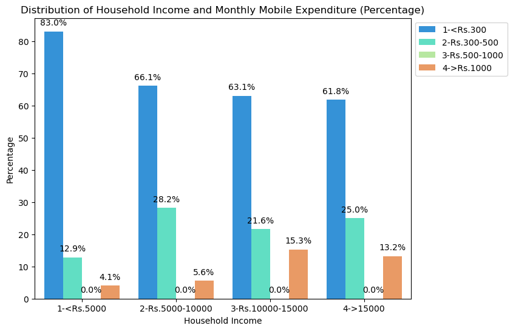

```python
# Assuming 'data2' is your DataFrame
columns_of_interest = ['Household Income', 'Monthly Mobile Expenditure 2']

# Filter the DataFrame for the selected columns
selected_data = data2[columns_of_interest].dropna()

# Calculate the percentages within each category
percentages = selected_data.groupby(['Household Income', 'Monthly Mobile Expenditure 2']).size() / selected_data.groupby(['Household Income']).size() * 100
percentages = percentages.reset_index(name='Percentage')

# Create a grouped bar chart using Seaborn
plt.figure(figsize=(8,6))
ax = sns.barplot(data=percentages, x='Household Income', y='Percentage', hue='Monthly Mobile Expenditure 2', palette='rainbow')

# Add data labels for each bar
for p in ax.patches:
    ax.annotate(f'{p.get_height():.1f}%', (p.get_x() + p.get_width() / 2., p.get_height()),
                ha='center', va='center', xytext=(0, 10), textcoords='offset points')

# Move the legend outside the plot
ax.legend(loc='upper left', bbox_to_anchor=(1, 1))

plt.xlabel('Household Income')
plt.ylabel('Percentage')
plt.title('Distribution of Household Income and Monthly Mobile Expenditure (Percentage)')
plt.show()
```

```python
#The cross table for Income × Cost has resulted in the following:


# Assuming 'data2' is your DataFrame
columns_of_interest = ['Household Income', 'Monthly Mobile Expenditure 2']

# Filter the DataFrame for the selected columns
selected_data = data2[columns_of_interest].dropna()

# Create a crosstabulation
cross_tab = pd.crosstab(selected_data['Monthly Mobile Expenditure 2'],selected_data['Household Income']
                        , margins=True, margins_name='Total')

# Display the crosstab
print(cross_tab)
cross_tab
```

```
Household Income              1-<Rs.5000  2-Rs.5000-10000  3-Rs.10000-15000  \
Monthly Mobile Expenditure 2
1-<Rs.300                            142              117                70
2-Rs.300-500                          22               50                24
4->Rs.1000                             7               10                17
Total                                171              177               111

Household Income              4->15000  Total
Monthly Mobile Expenditure 2
1-<Rs.300                           42    371
2-Rs.300-500                        17    113
4->Rs.1000                           9     43
Total                               68    527
```

| Household Income Monthly Mobile Expenditure 2 | 1-<Rs.5000 | 2-Rs.5000-10000 | 3-Rs.10000-15000 | 4->15000 | Total |
| --- | --- | --- | --- | --- | --- |
| 1-<Rs.300 | 142 | 117 | 70 | 42 | 371 |
| 2-Rs.300-500 | 22 | 50 | 24 | 17 | 113 |
| 4->Rs.1000 | 7 | 10 | 17 | 9 | 43 |
| Total | 171 | 177 | 111 | 68 | 527 |

```python
# Assuming 'data2' is your DataFrame
columns_of_interest = ['Household Income', 'Monthly Mobile Expenditure 2']

# Filter the DataFrame for the selected columns
selected_data = data2[columns_of_interest].dropna()

# Create a crosstabulation with observed counts
observed_cross_tab = pd.crosstab(selected_data['Monthly Mobile Expenditure 2'], selected_data['Household Income'], margins=True, margins_name='Total')

# Calculate expected counts using chi-squared test
_, _, _, expected = chi2_contingency(observed_cross_tab)

# Create a DataFrame for expected counts
expected_cross_tab = pd.DataFrame(expected, columns=observed_cross_tab.columns, index=observed_cross_tab.index)

# Display both observed and expected crosstabs
# print("Observed Counts:")
# print(observed_cross_tab)

# print("\nExpected Counts:")
# print(expected_cross_tab)

# Combine observed and expected counts into a single DataFrame
combined_cross_tab = pd.concat([observed_cross_tab, expected_cross_tab], keys=['Observed', 'Expected'], axis=0)

# Display the combined crosstab
# print(combined_cross_tab)

combined_cross_tab
```

|  | Household Income Monthly Mobile Expenditure 2 | 1-<Rs.5000 | 2-Rs.5000-10000 | 3-Rs.10000-15000 | 4->15000 | Total |
| --- | --- | --- | --- | --- | --- | --- |
| Observed | 1-<Rs.300 | 142.000000 | 117.000000 | 70.000000 | 42.000000 | 371.0 |
|  | 2-Rs.300-500 | 22.000000 | 50.000000 | 24.000000 | 17.000000 | 113.0 |
|  | 4->Rs.1000 | 7.000000 | 10.000000 | 17.000000 | 9.000000 | 43.0 |
|  | Total | 171.000000 | 177.000000 | 111.000000 | 68.000000 | 527.0 |
| Expected | 1-<Rs.300 | 120.381404 | 124.605313 | 78.142315 | 47.870968 | 371.0 |
|  | 2-Rs.300-500 | 36.666034 | 37.952562 | 23.800759 | 14.580645 | 113.0 |
|  | 4->Rs.1000 | 13.952562 | 14.442125 | 9.056926 | 5.548387 | 43.0 |
|  | Total | 171.000000 | 177.000000 | 111.000000 | 68.000000 | 527.0 |

```python
# Assuming 'data2' is your DataFrame
columns_of_interest = ['Household Income', 'Monthly Mobile Expenditure 2']

# Filter the DataFrame for the selected columns
selected_data = data2[columns_of_interest].dropna()

# Create a crosstabulation with observed counts
observed_cross_tab = pd.crosstab(selected_data['Monthly Mobile Expenditure 2'], selected_data['Household Income'], margins=True, margins_name='Total')

# Calculate expected counts using chi-squared test
_, _, _, expected = chi2_contingency(observed_cross_tab)

# Create DataFrames for observed and expected counts
observed_df = pd.DataFrame(observed_cross_tab.values, columns=observed_cross_tab.columns, index=observed_cross_tab.index)
expected_df = pd.DataFrame(expected, columns=observed_cross_tab.columns, index=observed_cross_tab.index)

# Calculate percentages within each income group
observed_percentages = observed_df.div(observed_df.loc['Total']) * 100
#expected_percentages = expected_df.div(expected_df.loc['Total']) * 100

# Combine observed and expected counts and percentages into a single DataFrame
combined_cross_tab = pd.concat([observed_df, expected_df, observed_percentages], axis=0,
                               keys=['Observed', 'Expected',  'Observed (%)'])

# Display the combined crosstab with percentages
#print(combined_cross_tab)
combined_cross_tab
```

|  | Household Income Monthly Mobile Expenditure 2 | 1-<Rs.5000 | 2-Rs.5000-10000 | 3-Rs.10000-15000 | 4->15000 | Total |
| --- | --- | --- | --- | --- | --- | --- |
| Observed | 1-<Rs.300 | 142.000000 | 117.000000 | 70.000000 | 42.000000 | 371.000000 |
|  | 2-Rs.300-500 | 22.000000 | 50.000000 | 24.000000 | 17.000000 | 113.000000 |
|  | 4->Rs.1000 | 7.000000 | 10.000000 | 17.000000 | 9.000000 | 43.000000 |
|  | Total | 171.000000 | 177.000000 | 111.000000 | 68.000000 | 527.000000 |
| Expected | 1-<Rs.300 | 120.381404 | 124.605313 | 78.142315 | 47.870968 | 371.000000 |
|  | 2-Rs.300-500 | 36.666034 | 37.952562 | 23.800759 | 14.580645 | 113.000000 |
|  | 4->Rs.1000 | 13.952562 | 14.442125 | 9.056926 | 5.548387 | 43.000000 |
|  | Total | 171.000000 | 177.000000 | 111.000000 | 68.000000 | 527.000000 |
| Observed (%) | 1-<Rs.300 | 83.040936 | 66.101695 | 63.063063 | 61.764706 | 70.398482 |
|  | 2-Rs.300-500 | 12.865497 | 28.248588 | 21.621622 | 25.000000 | 21.442125 |
|  | 4->Rs.1000 | 4.093567 | 5.649718 | 15.315315 | 13.235294 | 8.159393 |
|  | Total | 100.000000 | 100.000000 | 100.000000 | 100.000000 | 100.000000 |

##### Clearly, there are discrepancies between the actual frequencies and the expected frequencies. Are these differences statistically significant? To know this, Pearson’s Chi-square test is conducted, and the results are presented in the following table:

```python
# Assuming 'data2' is your DataFrame
columns_of_interest = ['Household Income', 'Monthly Mobile Expenditure 2']

# Filter the DataFrame for the selected columns
selected_data = data2[columns_of_interest].dropna()

# Create a crosstabulation with observed counts
observed_cross_tab = pd.crosstab(selected_data['Monthly Mobile Expenditure 2'], selected_data['Household Income'])

# Perform chi-squared test
chi2_stat, p_value, dof, expected = chi2_contingency(observed_cross_tab)

# Calculate minimum expected count
min_expected_count = np.min(expected)

# Count cells with expected count less than 5
cells_with_low_expected_count = np.sum(expected < 5)
cells_with_low_expected_count_pct=cells_with_low_expected_count/(observed_cross_tab.size)

# Display chi-square test results in a table
table = [
    ["Pearson Chi-Square", chi2_stat],
    ["Likelihood Ratio", chi2_contingency(observed_cross_tab, lambda_='log-likelihood')[0]],
    ["Linear-by-Linear Association", chi2_contingency(observed_cross_tab, correction=True)[0]],
    ["N of Valid Cases", selected_data.shape[0]],
    ["df", dof],
    ["Asymp. Sig (2-sided) - P-value", p_value],
    ["Minimum Expected Count", min_expected_count],
    [f"{cells_with_low_expected_count} cells ({cells_with_low_expected_count_pct}%) have expected count less than 5."]
]

print("\nChi-Square Test Results:")
print(tabulate(table, headers=[ "Value"]))
```

```
Chi-Square Test Results:
                                                         Value
-----------------------------------------------  -------------
Pearson Chi-Square                                29.9528
Likelihood Ratio                                  29.5948
Linear-by-Linear Association                      29.9528
N of Valid Cases                                 527
df                                                 6
Asymp. Sig (2-sided) - P-value                     4.01283e-05
Minimum Expected Count                             5.54839
0 cells (0.0%) have expected count less than 5.
```

To measure the strength of association between categorical variables, SPSS offers several measures of association. These measures are grouped into two categories namely nominal and ordinal. Note that both the classification variables in the above crosstable are ordinal in nature. Thus, it is appropriate to use ordinal measure of association to assess the strength. Somers’ d is one such measure. Somers’ d is an **ordinal directional measure** that indicates the significance, strength and direction of the relationship between the row and column variables of a cross tabulation. A low significance value (typically less than 0.05) indicates that there is a relationship between the two variables. The value of the statistic can range from -1 to 1. Negative values indicate a negative relationship, and positive values indicate a positive relationship. Somers’ d is appropriate when both variables are ordinal, categorical variables.

```python
from scipy.stats import somersd

# Assuming 'data2' is your DataFrame
columns_of_interest = ['Household Income', 'Monthly Mobile Expenditure 2']

# Filter the DataFrame for the selected columns
selected_data = data2[columns_of_interest].dropna()

# Calculate Somers' d in both directions
result1 = somersd(selected_data['Monthly Mobile Expenditure 2'], selected_data['Household Income'])
result2 = somersd(selected_data['Household Income'], selected_data['Monthly Mobile Expenditure 2'])

# Access the Somers' d statistic from the result objects
somersd_statistic1 = result1.statistic
somersd_statistic2 = result2.statistic

# Calculate the average of symmetric Somers' D
symmetric_somersd = (somersd_statistic1 + somersd_statistic2) / 2

# Calculate the standard error of Somers' D
n = len(selected_data)
se_d1 = np.sqrt(2 * (1 - somersd_statistic1 ** 2) / (n * (n - 1)))
se_d2 = np.sqrt(2 * (1 - somersd_statistic2 ** 2) / (n * (n - 1)))
se_ds = np.sqrt(2 * (1 - symmetric_somersd ** 2) / (n * (n - 1)))

# Calculate the asymptotic standard error (ASE) without assuming the null hypothesis
ase_d1 = np.sqrt(2 * (1 - somersd_statistic1 ** 2) / n)
ase_d2 = np.sqrt(2 * (1 - somersd_statistic2 ** 2) / n)
ase_ds = np.sqrt(2 * (1 - symmetric_somersd ** 2) / n)


# Create a list of dictionaries for the table with rounded values
table = [
    {"": "Symmetric Somers' D:", "Value": round(symmetric_somersd, 3), "P-value": None, "Standard Error": round(se_ds, 3), "Asymptotic Standard Error": round(ase_ds, 3)},
    {"": "Handset Cost Dependent Somers' D:", "Value": round(somersd_statistic2, 3), "P-value": round(result2.pvalue, 3), "Standard Error": round(se_d2, 3), "Asymptotic Standard Error": round(ase_d2, 3)},
    {"": "Income Dependent Somers' D:", "Value": round(somersd_statistic1, 3), "P-value": round(result1.pvalue, 3), "Standard Error": round(se_d1, 3), "Asymptotic Standard Error": round(ase_d1, 3)},


]

# Print the table using the tabulate library
print("\nSomers' d Test Results:")
print(tabulate(table, headers="keys", tablefmt="pretty"))
```

```
Somers' d Test Results:
+-----------------------------------+-------+---------+----------------+---------------------------+
|                                   | Value | P-value | Standard Error | Asymptotic Standard Error |
+-----------------------------------+-------+---------+----------------+---------------------------+
|       Symmetric Somers' D:        | 0.176 |         |     0.003      |           0.061           |
| Handset Cost Dependent Somers' D: | 0.136 |   0.0   |     0.003      |           0.061           |
|    Income Dependent Somers' D:    | 0.216 |   0.0   |     0.003      |           0.06            |
+-----------------------------------+-------+---------+----------------+---------------------------+
```

# Chapter 3

# Analysis of Handset Selection

## 3.1 Introduction

Factor Analysis is a popular dimension reduction technique. Using which we can study the correlation structure among the variables. Factor analysis partitions the manifest variables in to groups and each partition signifies the effect of a latent variable called common factor. These new variables stand for constructs that cannot be directly measurable. Such an analysis is vital in different fields of research. For example, in a marketing research, companies spends crores of rupees towards the advertisement of their products. Factor analysis may be used in order to know whether their spending towards advertisement is really worth.

## Objectives

- What are the factors that influence a student in the selection of a mobile phone?
- In the selection of a handset, are the influencing factors the same for rural as well as urban student population?
- In the selection of a handset, is there any gender difference among the influencing factors?
- What for students are using mobile phones?

In section-2 of this Chapter, we will analyze the factors influencing the selection of a handset and Section-3 describes what for a student is using a mobile.

## 3.2 Factors Influencing in the Handset Selection

Our sample consists of 527 students selected from four categories namely intermediate, graduate, post-graduate and research scholars. The category graduate includes students from usual 3-year degree courses as well as professional courses like engineering. Similarly, the post-graduate category includes engineering students. One of our objectives is to know about the factors that actually influence students in the selection of their mobiles. For this purpose we have asked the sampling units to rate several variables on a 5-point semantic Likert-scale. The data so obtained is analyzed, in this section, using Factor procedure of SPSS package.

### 3.2.1 Data Screening

Given a set of variables, SPSS will nearly always find a factor solution to that set of variables. The solution will not have any real meaning if the variables analyzed are not sensible. There are several techniques that can be used to know whether we can proceed with the factor analyzing the data set. Some of the popular procedures one can adopt are:

- Study correlations among the variables.
- Anti-Image Matrix.
- Kaiser-Meyer-Olkin Measure of Sampling Adequacy.
- Bartlett’s Test of Sphericity.
- Cluster Analysis.

### 3.2.2 Correlation Table:

For the purpose of knowing the influencing factors in the selection of handsets among student population, we have included 21 variables in our project(see the Appendix). We have obtained the correlation matrix for all the 21 variables. There are 8 variables left after screening the unimportant variables. These correlations are presented in the Correlation Table. This table also shows the groups of variables on the basis of correlations with other variables. Note that the correlation table also outputs the determinant value. This option is vital for testing multicollinearity or singularity. The determinant should be greater than 0.00001.

When there are large number of variables, inspecting the correlation table is clumsy. In such cases, one can resort to Matrix-Scatter Plot to asses the overall correlations of various variables with the other variables. As the variables are measured on Likert Scale, this option is not useful in present problem.

```python
data2.columns
```

```
Index(['Record_ID', 'Age', 'Gender', 'Education', 'Father Occupation',
       'Household Income', 'Native (Rural/Urban)',
       'Handset Type(Color/ Black & white)', 'Handset Brand',
       'Handset Selection Reason', 'Handset Cost', 'Handset Age',
       'Calls Receiving per day', 'SMS Receiving per day',
       'SMS Sending per day', 'Frequent Communication Type',
       'Feel safe and secure with mobile', 'Monthly Mobile Expenditure',
       'Current Service Provider', 'Current Service Provider Age',
       'SP - Influence Rating for Signal',
       'SP - Influence Rating for Customer care',
       'SP - Influence Rating for Electronic media',
       'SP - Influence Rating for Hoardings',
       'SP - Influence Rating for Friends',
       'SP - Influence Rating for Family members',
       'SP - Influence Rating for Print media',
       'SP - Influence Rating for Call costs',
       'HS - Influence Rating for Brand',
       'HS - Influence Rating for Battery back up',
       'HS - Influence Rating for Keypad', 'HS - Influence Rating for Display',
       'HS - Influence Rating for Sound',
       'HS - Influence Rating for Size of the screen',
       'HS - Influence Rating for Electronic media',
       'HS - Influence Rating for Print media',
       'HS - Influence Rating for Hoardings',
       'HS - Influence Rating for Friends',
       'HS - Influence Rating for Family members',
       'HS - Influence Rating for Voice clarity',
       'HS - Influence Rating for MP3 facility',
       'HS - Influence Rating for Bluetooth',
       'HS - Influence Rating for Camera pixels',
       'HS - Influence Rating for FM radio', 'HS - Influence Rating for Games',
       'HS - Influence Rating for Video',
       'HS - Influence Rating for Memory size',
       'HS - Influence Rating for Price', 'HS - Influence Rating for Stylish',
       'Stylish Handset Brand', 'More Models Handset Brand',
       'User friendly Handset Brand', 'Reasonable prices Handset Brand',
       'Added features Handset Brand', 'Customer service Handset Brand',
       'Advertisements Handset Brand', 'Sales promotions Handset Brand',
       'Available service centers Handset Brand', 'Durability Handset Brand',
       'Overall, I like the Handset Brand', 'User friendly Service Provider',
       'Added features Service Provider', 'Customer service Service Provider',
       'Advertisements Service Provider', 'Sales promotions Service Provider',
       'Available service centers Service Provider',
       'Overall, I like Service Provider', 'All my friends use',
       'Old fashioned', 'Prestige', 'Secure', 'Show-off', 'Life style',
       'Communication', 'Facilities', 'Life easier', 'Call Friends and Family',
       'Mostly use SMS', 'Music or Videos', 'Games',
       'Monthly Mobile Expenditure 2'],
      dtype='object', name='Feature')
```

```python
HS_Influence_Columns = ['HS - Influence Rating for Brand',
                       'HS - Influence Rating for Battery back up',
                       'HS - Influence Rating for Keypad',
                       'HS - Influence Rating for Display',
                       'HS - Influence Rating for Sound',
                       'HS - Influence Rating for Size of the screen',
                       'HS - Influence Rating for Electronic media',
                       'HS - Influence Rating for Print media',
                       'HS - Influence Rating for Hoardings',
                       'HS - Influence Rating for Friends',
                       'HS - Influence Rating for Family members',
                       'HS - Influence Rating for Voice clarity',
                       'HS - Influence Rating for MP3 facility',
                       'HS - Influence Rating for Bluetooth',
                       'HS - Influence Rating for Camera pixels',
                       'HS - Influence Rating for FM radio',
                       'HS - Influence Rating for Games',
                       'HS - Influence Rating for Video',
                       'HS - Influence Rating for Memory size',
                       'HS - Influence Rating for Price',
                       'HS - Influence Rating for Stylish']

data_HS_Factor = data2[HS_Influence_Columns]
data_HS_Factor.columns
```

```
Index(['HS - Influence Rating for Brand',
       'HS - Influence Rating for Battery back up',
       'HS - Influence Rating for Keypad', 'HS - Influence Rating for Display',
       'HS - Influence Rating for Sound',
       'HS - Influence Rating for Size of the screen',
       'HS - Influence Rating for Electronic media',
       'HS - Influence Rating for Print media',
       'HS - Influence Rating for Hoardings',
       'HS - Influence Rating for Friends',
       'HS - Influence Rating for Family members',
       'HS - Influence Rating for Voice clarity',
       'HS - Influence Rating for MP3 facility',
       'HS - Influence Rating for Bluetooth',
       'HS - Influence Rating for Camera pixels',
       'HS - Influence Rating for FM radio', 'HS - Influence Rating for Games',
       'HS - Influence Rating for Video',
       'HS - Influence Rating for Memory size',
       'HS - Influence Rating for Price', 'HS - Influence Rating for Stylish'],
      dtype='object', name='Feature')
```

```python
data_HS_Factor.columns = data_HS_Factor.columns.str.replace('HS - Influence Rating for ', '')
print(data_HS_Factor.columns)
data_HS_Factor.head()
```

```
Index(['Brand', 'Battery back up', 'Keypad', 'Display', 'Sound',
       'Size of the screen', 'Electronic media', 'Print media', 'Hoardings',
       'Friends', 'Family members', 'Voice clarity', 'MP3 facility',
       'Bluetooth', 'Camera pixels', 'FM radio', 'Games', 'Video',
       'Memory size', 'Price', 'Stylish'],
      dtype='object', name='Feature')
```

| Feature | Brand | Battery back up | Keypad | Display | Sound | Size of the screen | Electronic media | Print media | Hoardings | Friends | Family members | Voice clarity | MP3 facility | Bluetooth | Camera pixels | FM radio | Games | Video | Memory size | Price | Stylish |
| --- | --- | --- | --- | --- | --- | --- | --- | --- | --- | --- | --- | --- | --- | --- | --- | --- | --- | --- | --- | --- | --- |
| 0 | 5 | 4 | 4 | 4 | 3 | 3 | 3 | 2 | 2 | 4 | 4 | 5 | 3 | 3 | 3 | 4 | 4 | 2 | 4 | 5 | 4 |
| 1 | 3 | 3 | 5 | 4 | 4 | 5 | 4 | 4 | 4 | 5 | 3 | 3 | 1 | 1 | 1 | 5 | 3 | 1 | 2 | 4 | 5 |
| 2 | 5 | 5 | 4 | 4 | 4 | 4 | 3 | 3 | 3 | 5 | 5 | 4 | 4 | 3 | 3 | 4 | 3 | 3 | 4 | 4 | 4 |
| 3 | 4 | 4 | 4 | 4 | 3 | 4 | 4 | 3 | 4 | 4 | 4 | 4 | 4 | 4 | 3 | 4 | 4 | 4 | 4 | 4 | 4 |
| 4 | 5 | 4 | 5 | 5 | 5 | 5 | 5 | 5 | 5 | 4 | 5 | 5 | 5 | 3 | 3 | 5 | 5 | 3 | 3 | 5 | 5 |

```python
data_HS_Factor.corr().style.applymap(highlight_cell)
```

| Feature | Brand | Battery back up | Keypad | Display | Sound | Size of the screen | Electronic media | Print media | Hoardings | Friends | Family members | Voice clarity | MP3 facility | Bluetooth | Camera pixels | FM radio | Games | Video | Memory size | Price | Stylish |
| --- | --- | --- | --- | --- | --- | --- | --- | --- | --- | --- | --- | --- | --- | --- | --- | --- | --- | --- | --- | --- | --- |
| Brand | 1.000000 | 0.447500 | 0.368049 | 0.352448 | 0.299773 | 0.219962 | 0.241112 | 0.238421 | 0.202074 | 0.220499 | 0.205741 | 0.189865 | 0.208792 | 0.203259 | 0.226424 | 0.251729 | 0.181322 | 0.219793 | 0.208544 | 0.111346 | 0.285657 |
| Battery back up | 0.447500 | 1.000000 | 0.455116 | 0.473122 | 0.356497 | 0.275212 | 0.183919 | 0.156460 | 0.128429 | 0.219719 | 0.188218 | 0.313370 | 0.188104 | 0.177044 | 0.175327 | 0.187393 | 0.174319 | 0.151544 | 0.194127 | 0.207753 | 0.226921 |
| Keypad | 0.368049 | 0.455116 | 1.000000 | 0.550146 | 0.463320 | 0.273884 | 0.287988 | 0.297248 | 0.266476 | 0.291228 | 0.211269 | 0.291135 | 0.140184 | 0.163924 | 0.176070 | 0.226731 | 0.243890 | 0.166411 | 0.173915 | 0.153351 | 0.279279 |
| Display | 0.352448 | 0.473122 | 0.550146 | 1.000000 | 0.515270 | 0.338573 | 0.266246 | 0.291500 | 0.196218 | 0.251557 | 0.241758 | 0.409060 | 0.232849 | 0.224646 | 0.216971 | 0.231296 | 0.245455 | 0.226117 | 0.188534 | 0.153898 | 0.311172 |
| Sound | 0.299773 | 0.356497 | 0.463320 | 0.515270 | 1.000000 | 0.411655 | 0.238118 | 0.249039 | 0.177031 | 0.324270 | 0.315028 | 0.401818 | 0.216129 | 0.198162 | 0.210070 | 0.232918 | 0.259878 | 0.212409 | 0.219263 | 0.240665 | 0.359297 |
| Size of the screen | 0.219962 | 0.275212 | 0.273884 | 0.338573 | 0.411655 | 1.000000 | 0.378187 | 0.410941 | 0.264674 | 0.290560 | 0.239298 | 0.345437 | 0.305405 | 0.290902 | 0.322440 | 0.288611 | 0.269994 | 0.278295 | 0.346447 | 0.264013 | 0.380629 |
| Electronic media | 0.241112 | 0.183919 | 0.287988 | 0.266246 | 0.238118 | 0.378187 | 1.000000 | 0.754414 | 0.636217 | 0.293009 | 0.240326 | 0.252094 | 0.373971 | 0.344800 | 0.343241 | 0.319687 | 0.209542 | 0.341613 | 0.323455 | 0.175582 | 0.209705 |
| Print media | 0.238421 | 0.156460 | 0.297248 | 0.291500 | 0.249039 | 0.410941 | 0.754414 | 1.000000 | 0.651765 | 0.288497 | 0.240645 | 0.240040 | 0.376907 | 0.353263 | 0.370847 | 0.351341 | 0.284418 | 0.349543 | 0.353232 | 0.182963 | 0.220291 |
| Hoardings | 0.202074 | 0.128429 | 0.266476 | 0.196218 | 0.177031 | 0.264674 | 0.636217 | 0.651765 | 1.000000 | 0.331637 | 0.177769 | 0.108796 | 0.266229 | 0.247542 | 0.318332 | 0.303566 | 0.236877 | 0.260842 | 0.296166 | 0.117033 | 0.148987 |
| Friends | 0.220499 | 0.219719 | 0.291228 | 0.251557 | 0.324270 | 0.290560 | 0.293009 | 0.288497 | 0.331637 | 1.000000 | 0.524864 | 0.303580 | 0.151109 | 0.164342 | 0.159330 | 0.179428 | 0.213524 | 0.151927 | 0.193085 | 0.167739 | 0.330806 |
| Family members | 0.205741 | 0.188218 | 0.211269 | 0.241758 | 0.315028 | 0.239298 | 0.240326 | 0.240645 | 0.177769 | 0.524864 | 1.000000 | 0.305155 | 0.141054 | 0.102727 | 0.067721 | 0.154411 | 0.213426 | 0.093876 | 0.161557 | 0.196582 | 0.271532 |
| Voice clarity | 0.189865 | 0.313370 | 0.291135 | 0.409060 | 0.401818 | 0.345437 | 0.252094 | 0.240040 | 0.108796 | 0.303580 | 0.305155 | 1.000000 | 0.333644 | 0.282737 | 0.263019 | 0.294226 | 0.320801 | 0.231258 | 0.249381 | 0.243936 | 0.367314 |
| MP3 facility | 0.208792 | 0.188104 | 0.140184 | 0.232849 | 0.216129 | 0.305405 | 0.373971 | 0.376907 | 0.266229 | 0.151109 | 0.141054 | 0.333644 | 1.000000 | 0.802965 | 0.730100 | 0.475656 | 0.310699 | 0.720118 | 0.616411 | 0.167273 | 0.338187 |
| Bluetooth | 0.203259 | 0.177044 | 0.163924 | 0.224646 | 0.198162 | 0.290902 | 0.344800 | 0.353263 | 0.247542 | 0.164342 | 0.102727 | 0.282737 | 0.802965 | 1.000000 | 0.794365 | 0.445135 | 0.310691 | 0.732494 | 0.585997 | 0.182164 | 0.373247 |
| Camera pixels | 0.226424 | 0.175327 | 0.176070 | 0.216971 | 0.210070 | 0.322440 | 0.343241 | 0.370847 | 0.318332 | 0.159330 | 0.067721 | 0.263019 | 0.730100 | 0.794365 | 1.000000 | 0.525500 | 0.347600 | 0.787034 | 0.619238 | 0.192735 | 0.381609 |
| FM radio | 0.251729 | 0.187393 | 0.226731 | 0.231296 | 0.232918 | 0.288611 | 0.319687 | 0.351341 | 0.303566 | 0.179428 | 0.154411 | 0.294226 | 0.475656 | 0.445135 | 0.525500 | 1.000000 | 0.408284 | 0.484568 | 0.424790 | 0.234218 | 0.364601 |
| Games | 0.181322 | 0.174319 | 0.243890 | 0.245455 | 0.259878 | 0.269994 | 0.209542 | 0.284418 | 0.236877 | 0.213524 | 0.213426 | 0.320801 | 0.310699 | 0.310691 | 0.347600 | 0.408284 | 1.000000 | 0.378922 | 0.346574 | 0.237919 | 0.329868 |
| Video | 0.219793 | 0.151544 | 0.166411 | 0.226117 | 0.212409 | 0.278295 | 0.341613 | 0.349543 | 0.260842 | 0.151927 | 0.093876 | 0.231258 | 0.720118 | 0.732494 | 0.787034 | 0.484568 | 0.378922 | 1.000000 | 0.633084 | 0.183343 | 0.348966 |
| Memory size | 0.208544 | 0.194127 | 0.173915 | 0.188534 | 0.219263 | 0.346447 | 0.323455 | 0.353232 | 0.296166 | 0.193085 | 0.161557 | 0.249381 | 0.616411 | 0.585997 | 0.619238 | 0.424790 | 0.346574 | 0.633084 | 1.000000 | 0.279794 | 0.407858 |
| Price | 0.111346 | 0.207753 | 0.153351 | 0.153898 | 0.240665 | 0.264013 | 0.175582 | 0.182963 | 0.117033 | 0.167739 | 0.196582 | 0.243936 | 0.167273 | 0.182164 | 0.192735 | 0.234218 | 0.237919 | 0.183343 | 0.279794 | 1.000000 | 0.380925 |
| Stylish | 0.285657 | 0.226921 | 0.279279 | 0.311172 | 0.359297 | 0.380629 | 0.209705 | 0.220291 | 0.148987 | 0.330806 | 0.271532 | 0.367314 | 0.338187 | 0.373247 | 0.381609 | 0.364601 | 0.329868 | 0.348966 | 0.407858 | 0.380925 | 1.000000 |

```python
import pandas as pd
import numpy as np
from scipy.stats import pearsonr

# Assuming 'df' is your DataFrame
# Create a correlation matrix
correlation_matrix = data_HS_Factor.corr()

# Create an empty DataFrame for p-values
p_values_matrix = pd.DataFrame(np.zeros_like(correlation_matrix)
                               , columns=correlation_matrix.columns
                               , index=correlation_matrix.index)

# Calculate p-values for each pair of variables
for i in range(len(correlation_matrix.columns)):
    for j in range(i+1, len(correlation_matrix.columns)):
        corr, p_value = pearsonr(data_HS_Factor[correlation_matrix.columns[i]], data_HS_Factor[correlation_matrix.columns[j]])
        p_values_matrix.iloc[i, j] = p_value
        p_values_matrix.iloc[j, i] = p_value

# Print the correlation matrix
print("Correlation Matrix:")
display(correlation_matrix.style.applymap(highlight_cell))

# Print the p-values matrix
print("\nP-Values Matrix:")
display(p_values_matrix.style.applymap(highlight_cell))
```

```
Correlation Matrix:
```

| Feature | Brand | Battery back up | Keypad | Display | Sound | Size of the screen | Electronic media | Print media | Hoardings | Friends | Family members | Voice clarity | MP3 facility | Bluetooth | Camera pixels | FM radio | Games | Video | Memory size | Price | Stylish |
| --- | --- | --- | --- | --- | --- | --- | --- | --- | --- | --- | --- | --- | --- | --- | --- | --- | --- | --- | --- | --- | --- |
| Brand | 1.000000 | 0.447500 | 0.368049 | 0.352448 | 0.299773 | 0.219962 | 0.241112 | 0.238421 | 0.202074 | 0.220499 | 0.205741 | 0.189865 | 0.208792 | 0.203259 | 0.226424 | 0.251729 | 0.181322 | 0.219793 | 0.208544 | 0.111346 | 0.285657 |
| Battery back up | 0.447500 | 1.000000 | 0.455116 | 0.473122 | 0.356497 | 0.275212 | 0.183919 | 0.156460 | 0.128429 | 0.219719 | 0.188218 | 0.313370 | 0.188104 | 0.177044 | 0.175327 | 0.187393 | 0.174319 | 0.151544 | 0.194127 | 0.207753 | 0.226921 |
| Keypad | 0.368049 | 0.455116 | 1.000000 | 0.550146 | 0.463320 | 0.273884 | 0.287988 | 0.297248 | 0.266476 | 0.291228 | 0.211269 | 0.291135 | 0.140184 | 0.163924 | 0.176070 | 0.226731 | 0.243890 | 0.166411 | 0.173915 | 0.153351 | 0.279279 |
| Display | 0.352448 | 0.473122 | 0.550146 | 1.000000 | 0.515270 | 0.338573 | 0.266246 | 0.291500 | 0.196218 | 0.251557 | 0.241758 | 0.409060 | 0.232849 | 0.224646 | 0.216971 | 0.231296 | 0.245455 | 0.226117 | 0.188534 | 0.153898 | 0.311172 |
| Sound | 0.299773 | 0.356497 | 0.463320 | 0.515270 | 1.000000 | 0.411655 | 0.238118 | 0.249039 | 0.177031 | 0.324270 | 0.315028 | 0.401818 | 0.216129 | 0.198162 | 0.210070 | 0.232918 | 0.259878 | 0.212409 | 0.219263 | 0.240665 | 0.359297 |
| Size of the screen | 0.219962 | 0.275212 | 0.273884 | 0.338573 | 0.411655 | 1.000000 | 0.378187 | 0.410941 | 0.264674 | 0.290560 | 0.239298 | 0.345437 | 0.305405 | 0.290902 | 0.322440 | 0.288611 | 0.269994 | 0.278295 | 0.346447 | 0.264013 | 0.380629 |
| Electronic media | 0.241112 | 0.183919 | 0.287988 | 0.266246 | 0.238118 | 0.378187 | 1.000000 | 0.754414 | 0.636217 | 0.293009 | 0.240326 | 0.252094 | 0.373971 | 0.344800 | 0.343241 | 0.319687 | 0.209542 | 0.341613 | 0.323455 | 0.175582 | 0.209705 |
| Print media | 0.238421 | 0.156460 | 0.297248 | 0.291500 | 0.249039 | 0.410941 | 0.754414 | 1.000000 | 0.651765 | 0.288497 | 0.240645 | 0.240040 | 0.376907 | 0.353263 | 0.370847 | 0.351341 | 0.284418 | 0.349543 | 0.353232 | 0.182963 | 0.220291 |
| Hoardings | 0.202074 | 0.128429 | 0.266476 | 0.196218 | 0.177031 | 0.264674 | 0.636217 | 0.651765 | 1.000000 | 0.331637 | 0.177769 | 0.108796 | 0.266229 | 0.247542 | 0.318332 | 0.303566 | 0.236877 | 0.260842 | 0.296166 | 0.117033 | 0.148987 |
| Friends | 0.220499 | 0.219719 | 0.291228 | 0.251557 | 0.324270 | 0.290560 | 0.293009 | 0.288497 | 0.331637 | 1.000000 | 0.524864 | 0.303580 | 0.151109 | 0.164342 | 0.159330 | 0.179428 | 0.213524 | 0.151927 | 0.193085 | 0.167739 | 0.330806 |
| Family members | 0.205741 | 0.188218 | 0.211269 | 0.241758 | 0.315028 | 0.239298 | 0.240326 | 0.240645 | 0.177769 | 0.524864 | 1.000000 | 0.305155 | 0.141054 | 0.102727 | 0.067721 | 0.154411 | 0.213426 | 0.093876 | 0.161557 | 0.196582 | 0.271532 |
| Voice clarity | 0.189865 | 0.313370 | 0.291135 | 0.409060 | 0.401818 | 0.345437 | 0.252094 | 0.240040 | 0.108796 | 0.303580 | 0.305155 | 1.000000 | 0.333644 | 0.282737 | 0.263019 | 0.294226 | 0.320801 | 0.231258 | 0.249381 | 0.243936 | 0.367314 |
| MP3 facility | 0.208792 | 0.188104 | 0.140184 | 0.232849 | 0.216129 | 0.305405 | 0.373971 | 0.376907 | 0.266229 | 0.151109 | 0.141054 | 0.333644 | 1.000000 | 0.802965 | 0.730100 | 0.475656 | 0.310699 | 0.720118 | 0.616411 | 0.167273 | 0.338187 |
| Bluetooth | 0.203259 | 0.177044 | 0.163924 | 0.224646 | 0.198162 | 0.290902 | 0.344800 | 0.353263 | 0.247542 | 0.164342 | 0.102727 | 0.282737 | 0.802965 | 1.000000 | 0.794365 | 0.445135 | 0.310691 | 0.732494 | 0.585997 | 0.182164 | 0.373247 |
| Camera pixels | 0.226424 | 0.175327 | 0.176070 | 0.216971 | 0.210070 | 0.322440 | 0.343241 | 0.370847 | 0.318332 | 0.159330 | 0.067721 | 0.263019 | 0.730100 | 0.794365 | 1.000000 | 0.525500 | 0.347600 | 0.787034 | 0.619238 | 0.192735 | 0.381609 |
| FM radio | 0.251729 | 0.187393 | 0.226731 | 0.231296 | 0.232918 | 0.288611 | 0.319687 | 0.351341 | 0.303566 | 0.179428 | 0.154411 | 0.294226 | 0.475656 | 0.445135 | 0.525500 | 1.000000 | 0.408284 | 0.484568 | 0.424790 | 0.234218 | 0.364601 |
| Games | 0.181322 | 0.174319 | 0.243890 | 0.245455 | 0.259878 | 0.269994 | 0.209542 | 0.284418 | 0.236877 | 0.213524 | 0.213426 | 0.320801 | 0.310699 | 0.310691 | 0.347600 | 0.408284 | 1.000000 | 0.378922 | 0.346574 | 0.237919 | 0.329868 |
| Video | 0.219793 | 0.151544 | 0.166411 | 0.226117 | 0.212409 | 0.278295 | 0.341613 | 0.349543 | 0.260842 | 0.151927 | 0.093876 | 0.231258 | 0.720118 | 0.732494 | 0.787034 | 0.484568 | 0.378922 | 1.000000 | 0.633084 | 0.183343 | 0.348966 |
| Memory size | 0.208544 | 0.194127 | 0.173915 | 0.188534 | 0.219263 | 0.346447 | 0.323455 | 0.353232 | 0.296166 | 0.193085 | 0.161557 | 0.249381 | 0.616411 | 0.585997 | 0.619238 | 0.424790 | 0.346574 | 0.633084 | 1.000000 | 0.279794 | 0.407858 |
| Price | 0.111346 | 0.207753 | 0.153351 | 0.153898 | 0.240665 | 0.264013 | 0.175582 | 0.182963 | 0.117033 | 0.167739 | 0.196582 | 0.243936 | 0.167273 | 0.182164 | 0.192735 | 0.234218 | 0.237919 | 0.183343 | 0.279794 | 1.000000 | 0.380925 |
| Stylish | 0.285657 | 0.226921 | 0.279279 | 0.311172 | 0.359297 | 0.380629 | 0.209705 | 0.220291 | 0.148987 | 0.330806 | 0.271532 | 0.367314 | 0.338187 | 0.373247 | 0.381609 | 0.364601 | 0.329868 | 0.348966 | 0.407858 | 0.380925 | 1.000000 |

```
P-Values Matrix:
```

| Feature | Brand | Battery back up | Keypad | Display | Sound | Size of the screen | Electronic media | Print media | Hoardings | Friends | Family members | Voice clarity | MP3 facility | Bluetooth | Camera pixels | FM radio | Games | Video | Memory size | Price | Stylish |
| --- | --- | --- | --- | --- | --- | --- | --- | --- | --- | --- | --- | --- | --- | --- | --- | --- | --- | --- | --- | --- | --- |
| Brand | 0.000000 | 0.000000 | 0.000000 | 0.000000 | 0.000000 | 0.000000 | 0.000000 | 0.000000 | 0.000003 | 0.000000 | 0.000002 | 0.000011 | 0.000001 | 0.000003 | 0.000000 | 0.000000 | 0.000028 | 0.000000 | 0.000001 | 0.010527 | 0.000000 |
| Battery back up | 0.000000 | 0.000000 | 0.000000 | 0.000000 | 0.000000 | 0.000000 | 0.000022 | 0.000312 | 0.003142 | 0.000000 | 0.000014 | 0.000000 | 0.000014 | 0.000044 | 0.000052 | 0.000015 | 0.000057 | 0.000481 | 0.000007 | 0.000002 | 0.000000 |
| Keypad | 0.000000 | 0.000000 | 0.000000 | 0.000000 | 0.000000 | 0.000000 | 0.000000 | 0.000000 | 0.000000 | 0.000000 | 0.000001 | 0.000000 | 0.001253 | 0.000157 | 0.000048 | 0.000000 | 0.000000 | 0.000124 | 0.000060 | 0.000411 | 0.000000 |
| Display | 0.000000 | 0.000000 | 0.000000 | 0.000000 | 0.000000 | 0.000000 | 0.000000 | 0.000000 | 0.000006 | 0.000000 | 0.000000 | 0.000000 | 0.000000 | 0.000000 | 0.000000 | 0.000000 | 0.000000 | 0.000000 | 0.000013 | 0.000392 | 0.000000 |
| Sound | 0.000000 | 0.000000 | 0.000000 | 0.000000 | 0.000000 | 0.000000 | 0.000000 | 0.000000 | 0.000044 | 0.000000 | 0.000000 | 0.000000 | 0.000001 | 0.000005 | 0.000001 | 0.000000 | 0.000000 | 0.000001 | 0.000000 | 0.000000 | 0.000000 |
| Size of the screen | 0.000000 | 0.000000 | 0.000000 | 0.000000 | 0.000000 | 0.000000 | 0.000000 | 0.000000 | 0.000000 | 0.000000 | 0.000000 | 0.000000 | 0.000000 | 0.000000 | 0.000000 | 0.000000 | 0.000000 | 0.000000 | 0.000000 | 0.000000 | 0.000000 |
| Electronic media | 0.000000 | 0.000022 | 0.000000 | 0.000000 | 0.000000 | 0.000000 | 0.000000 | 0.000000 | 0.000000 | 0.000000 | 0.000000 | 0.000000 | 0.000000 | 0.000000 | 0.000000 | 0.000000 | 0.000001 | 0.000000 | 0.000000 | 0.000051 | 0.000001 |
| Print media | 0.000000 | 0.000312 | 0.000000 | 0.000000 | 0.000000 | 0.000000 | 0.000000 | 0.000000 | 0.000000 | 0.000000 | 0.000000 | 0.000000 | 0.000000 | 0.000000 | 0.000000 | 0.000000 | 0.000000 | 0.000000 | 0.000000 | 0.000024 | 0.000000 |
| Hoardings | 0.000003 | 0.003142 | 0.000000 | 0.000006 | 0.000044 | 0.000000 | 0.000000 | 0.000000 | 0.000000 | 0.000000 | 0.000041 | 0.012452 | 0.000000 | 0.000000 | 0.000000 | 0.000000 | 0.000000 | 0.000000 | 0.000000 | 0.007155 | 0.000601 |
| Friends | 0.000000 | 0.000000 | 0.000000 | 0.000000 | 0.000000 | 0.000000 | 0.000000 | 0.000000 | 0.000000 | 0.000000 | 0.000000 | 0.000000 | 0.000500 | 0.000151 | 0.000240 | 0.000034 | 0.000001 | 0.000466 | 0.000008 | 0.000109 | 0.000000 |
| Family members | 0.000002 | 0.000014 | 0.000001 | 0.000000 | 0.000000 | 0.000000 | 0.000000 | 0.000000 | 0.000041 | 0.000000 | 0.000000 | 0.000000 | 0.001168 | 0.018329 | 0.120489 | 0.000374 | 0.000001 | 0.031184 | 0.000196 | 0.000005 | 0.000000 |
| Voice clarity | 0.000011 | 0.000000 | 0.000000 | 0.000000 | 0.000000 | 0.000000 | 0.000000 | 0.000000 | 0.012452 | 0.000000 | 0.000000 | 0.000000 | 0.000000 | 0.000000 | 0.000000 | 0.000000 | 0.000000 | 0.000000 | 0.000000 | 0.000000 | 0.000000 |
| MP3 facility | 0.000001 | 0.000014 | 0.001253 | 0.000000 | 0.000001 | 0.000000 | 0.000000 | 0.000000 | 0.000000 | 0.000500 | 0.001168 | 0.000000 | 0.000000 | 0.000000 | 0.000000 | 0.000000 | 0.000000 | 0.000000 | 0.000000 | 0.000114 | 0.000000 |
| Bluetooth | 0.000003 | 0.000044 | 0.000157 | 0.000000 | 0.000005 | 0.000000 | 0.000000 | 0.000000 | 0.000000 | 0.000151 | 0.018329 | 0.000000 | 0.000000 | 0.000000 | 0.000000 | 0.000000 | 0.000000 | 0.000000 | 0.000000 | 0.000026 | 0.000000 |
| Camera pixels | 0.000000 | 0.000052 | 0.000048 | 0.000000 | 0.000001 | 0.000000 | 0.000000 | 0.000000 | 0.000000 | 0.000240 | 0.120489 | 0.000000 | 0.000000 | 0.000000 | 0.000000 | 0.000000 | 0.000000 | 0.000000 | 0.000000 | 0.000008 | 0.000000 |
| FM radio | 0.000000 | 0.000015 | 0.000000 | 0.000000 | 0.000000 | 0.000000 | 0.000000 | 0.000000 | 0.000000 | 0.000034 | 0.000374 | 0.000000 | 0.000000 | 0.000000 | 0.000000 | 0.000000 | 0.000000 | 0.000000 | 0.000000 | 0.000000 | 0.000000 |
| Games | 0.000028 | 0.000057 | 0.000000 | 0.000000 | 0.000000 | 0.000000 | 0.000001 | 0.000000 | 0.000000 | 0.000001 | 0.000001 | 0.000000 | 0.000000 | 0.000000 | 0.000000 | 0.000000 | 0.000000 | 0.000000 | 0.000000 | 0.000000 | 0.000000 |
| Video | 0.000000 | 0.000481 | 0.000124 | 0.000000 | 0.000001 | 0.000000 | 0.000000 | 0.000000 | 0.000000 | 0.000466 | 0.031184 | 0.000000 | 0.000000 | 0.000000 | 0.000000 | 0.000000 | 0.000000 | 0.000000 | 0.000000 | 0.000023 | 0.000000 |
| Memory size | 0.000001 | 0.000007 | 0.000060 | 0.000013 | 0.000000 | 0.000000 | 0.000000 | 0.000000 | 0.000000 | 0.000008 | 0.000196 | 0.000000 | 0.000000 | 0.000000 | 0.000000 | 0.000000 | 0.000000 | 0.000000 | 0.000000 | 0.000000 | 0.000000 |
| Price | 0.010527 | 0.000002 | 0.000411 | 0.000392 | 0.000000 | 0.000000 | 0.000051 | 0.000024 | 0.007155 | 0.000109 | 0.000005 | 0.000000 | 0.000114 | 0.000026 | 0.000008 | 0.000000 | 0.000000 | 0.000023 | 0.000000 | 0.000000 | 0.000000 |
| Stylish | 0.000000 | 0.000000 | 0.000000 | 0.000000 | 0.000000 | 0.000000 | 0.000001 | 0.000000 | 0.000601 | 0.000000 | 0.000000 | 0.000000 | 0.000000 | 0.000000 | 0.000000 | 0.000000 | 0.000000 | 0.000000 | 0.000000 | 0.000000 | 0.000000 |

```python
import pandas as pd
import numpy as np
from factor_analyzer import FactorAnalyzer
from factor_analyzer.factor_analyzer import calculate_kmo
from factor_analyzer.factor_analyzer import calculate_bartlett_sphericity

# Assuming 'data_HS_Factor' is your DataFrame
# Specify the number of factors
n_factors = 10

# Initialize FactorAnalyzer
fa = FactorAnalyzer(n_factors, rotation=None)

# Fit the model
fa.fit(data_HS_Factor)

# Obtain the factor loadings
factor_loadings = pd.DataFrame(fa.loadings_, index=data_HS_Factor.columns)

# Calculate Kaiser-Meyer-Olkin (KMO) Measure of Sampling Adequacy

kmo_per_variable, kmo_total = calculate_kmo(data_HS_Factor)

# Print the KMO values
print("Kaiser-Meyer-Olkin (KMO) Measure of Sampling Adequacy per variable:")
print(kmo_per_variable)
print("\nKaiser-Meyer-Olkin (KMO) Measure of Sampling Adequacy (Total):", kmo_total)

chi2_statistic,p_value = calculate_bartlett_sphericity(data_HS_Factor)

# Print the test statistics
print("\nBartlett's Test of Sphericity:")
print(f"Chi-Square Statistic: {chi2_statistic}")
print(f"P-value: {p_value}")
```

```
Kaiser-Meyer-Olkin (KMO) Measure of Sampling Adequacy per variable:
[0.89924419 0.86183536 0.89853055 0.89540982 0.92394103 0.94286954
 0.86282679 0.86729638 0.85747471 0.84080338 0.82888089 0.91518042
 0.9059546  0.89209979 0.90308777 0.95581706 0.93279876 0.91796229
 0.95219443 0.88549424 0.92260799]

Kaiser-Meyer-Olkin (KMO) Measure of Sampling Adequacy (Total): 0.9010115504729133

Bartlett's Test of Sphericity:
Chi-Square Statistic: 5210.445073973882
P-value: 0.0
```

**From the above KMO result, we note that the KMO value is *0.901.* From the above recommendations of Kaiser and Rice, it is appropriate to proceed with factor analysis of the data on hand.**

### 3.2.6 Cluster Analysis:

Another alternative is to cluster analyze the variables and inspect the dendrogram. This is a good option in present context.

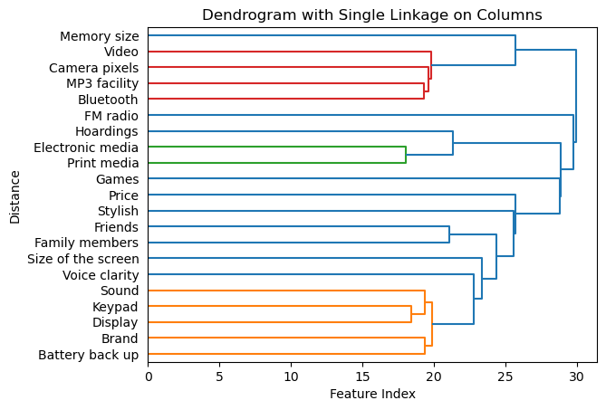

```python
from scipy.cluster.hierarchy import linkage, dendrogram

# Assuming 'data_HS_Factor' is your data matrix
# Transpose the data matrix to cluster on columns
data_transposed = data_HS_Factor.T

# Perform hierarchical clustering with single linkage
linkage_matrix = linkage(data_transposed, method='single')

# Create a dendrogram
#dendrogram(linkage_matrix, orientation='top', labels=data_HS_Factor.columns, distance_sort='descending', show_leaf_counts=True)

# Create a dendrogram with transposed orientation
dendrogram(linkage_matrix, orientation='right', labels=data_HS_Factor.columns
           , distance_sort='descending', show_leaf_counts=True)

# Add labels and title
plt.xlabel('Feature Index')
plt.ylabel('Distance')
plt.title('Dendrogram with Single Linkage on Columns')

# Show the plot
plt.show()
```

**From the Dendrogram, it is clearly evident that there are three groups of variables, signifying different aspects. This suggest that there are correlations between variables as well as the number of factors that can be extracted.**

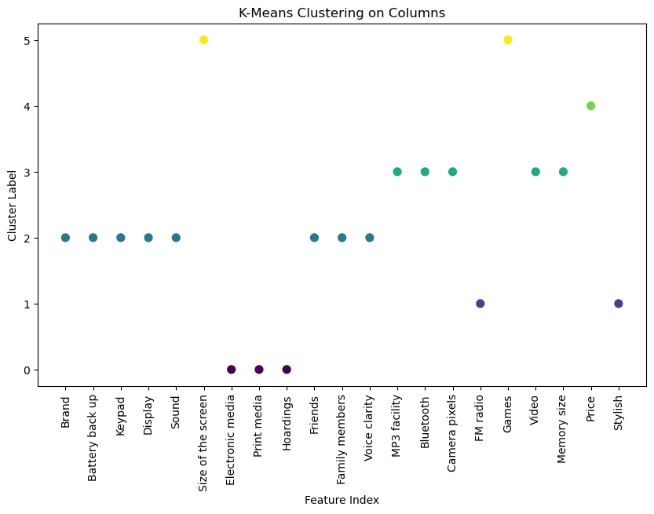

```python
import matplotlib.pyplot as plt
from sklearn.cluster import KMeans

# Assuming 'data_HS_Factor' is your data matrix
# Transpose the data matrix to cluster on columns
data_transposed = data_HS_Factor.T

# Specify the number of clusters (k)
num_clusters = 6  # You can adjust this based on your requirements

# Perform k-means clustering
kmeans = KMeans(n_clusters=num_clusters, random_state=42)
cluster_labels = kmeans.fit_predict(data_transposed)

# Visualize the results
plt.figure(figsize=(10, 6))
plt.scatter(data_transposed.index, cluster_labels, c=cluster_labels, cmap='viridis', marker='o', s=50)
plt.title('K-Means Clustering on Columns')
plt.xticks(rotation=90)
plt.xlabel('Feature Index')
plt.ylabel('Cluster Label')
plt.show()
```

```python
import pandas as pd
from factor_analyzer import FactorAnalyzer

# Assuming 'data_HS_Factor' is your DataFrame
# Specify the number of factors
n_factors = 3

# Create a FactorAnalyzer object
fa_woer = FactorAnalyzer(len(data_HS_Factor.columns),method='principal',rotation=None) #without extracation and rotation
fa_wer  = FactorAnalyzer(n_factors,method='principal', rotation="varimax")

# Fit the factor model to your data
fa_woer.fit(data_HS_Factor)
fa_wer.fit(data_HS_Factor)

# Get the variable names
features = data_HS_Factor.columns

# Get initial communalities
communalities_without_extraction_rotation = fa_woer.get_communalities()

# Get extracted communalities
communalities_with_extraction_rotation = fa_wer.get_communalities()

# Create a DataFrame with feature, initial communality, and extracted communality
communalities_table = pd.DataFrame({    'Feature': features,
                                    'Communalities (Initial)': communalities_without_extraction_rotation,
                                    'Communalities (With Extraction and Rotation)': communalities_with_extraction_rotation,
                                   })

# Display the communalities table
# print('\n',features)
# print('\n',communalities_without_rotation)
# print('\n',communalities_with_rotation,'\n')

communalities_table.style.applymap(highlight_cell)
```

|  | Feature | Communalities (Initial) | Communalities (With Extraction and Rotation) |
| --- | --- | --- | --- |
| 0 | Brand | 1.000000 | 0.305565 |
| 1 | Battery back up | 1.000000 | 0.448350 |
| 2 | Keypad | 1.000000 | 0.491550 |
| 3 | Display | 1.000000 | 0.535471 |
| 4 | Sound | 1.000000 | 0.534186 |
| 5 | Size of the screen | 1.000000 | 0.382207 |
| 6 | Electronic media | 1.000000 | 0.767796 |
| 7 | Print media | 1.000000 | 0.788377 |
| 8 | Hoardings | 1.000000 | 0.737310 |
| 9 | Friends | 1.000000 | 0.386403 |
| 10 | Family members | 1.000000 | 0.320768 |
| 11 | Voice clarity | 1.000000 | 0.416320 |
| 12 | MP3 facility | 1.000000 | 0.754092 |
| 13 | Bluetooth | 1.000000 | 0.772045 |
| 14 | Camera pixels | 1.000000 | 0.803458 |
| 15 | FM radio | 1.000000 | 0.439657 |
| 16 | Games | 1.000000 | 0.301096 |
| 17 | Video | 1.000000 | 0.766746 |
| 18 | Memory size | 1.000000 | 0.600867 |
| 19 | Price | 1.000000 | 0.196907 |
| 20 | Stylish | 1.000000 | 0.453419 |

```python
from factor_analyzer import FactorAnalyzer

# Assuming 'data_HS_Factor' is your DataFrame
# Specify the number of factors
n_factors = 9

# Create a FactorAnalyzer object
fa = FactorAnalyzer(len(data_HS_Factor.columns), method='principal',rotation='varimax')

# Fit the factor model to your data
fa.fit(data_HS_Factor)

# Get the explained variance
explained_variance = fa.get_factor_variance()

# Create a DataFrame with the total variance explained
total_variance_table = pd.DataFrame({
    'Factor': [f'Factor {i+1}' for i in range(len(data_HS_Factor.columns))],
    'SS Loadings': explained_variance[0],
    'Proportion Var': explained_variance[1],
    'Cumulative Var': explained_variance[2]
})

# Display the total variance table
print("Total Variance Explained Table:")
total_variance_table.style.applymap(highlight_cell)
```

```
Total Variance Explained Table:
```

|  | Factor | SS Loadings | Proportion Var | Cumulative Var |
| --- | --- | --- | --- | --- |
| 0 | Factor 1 | 3.527983 | 0.167999 | 0.167999 |
| 1 | Factor 2 | 0.963806 | 0.045896 | 0.213895 |
| 2 | Factor 3 | 1.096564 | 0.052217 | 0.266112 |
| 3 | Factor 4 | 1.033088 | 0.049195 | 0.315307 |
| 4 | Factor 5 | 1.038610 | 0.049458 | 0.364764 |
| 5 | Factor 6 | 1.030469 | 0.049070 | 0.413834 |
| 6 | Factor 7 | 1.027504 | 0.048929 | 0.462763 |
| 7 | Factor 8 | 1.012489 | 0.048214 | 0.510977 |
| 8 | Factor 9 | 1.022477 | 0.048689 | 0.559666 |
| 9 | Factor 10 | 0.962137 | 0.045816 | 0.605482 |
| 10 | Factor 11 | 1.003432 | 0.047782 | 0.653265 |
| 11 | Factor 12 | 0.952925 | 0.045377 | 0.698642 |
| 12 | Factor 13 | 0.987753 | 0.047036 | 0.745678 |
| 13 | Factor 14 | 0.759410 | 0.036162 | 0.781840 |
| 14 | Factor 15 | 1.004751 | 0.047845 | 0.829686 |
| 15 | Factor 16 | 1.014496 | 0.048309 | 0.877995 |
| 16 | Factor 17 | 1.121274 | 0.053394 | 0.931389 |
| 17 | Factor 18 | 0.313894 | 0.014947 | 0.946336 |
| 18 | Factor 19 | 0.681454 | 0.032450 | 0.978786 |
| 19 | Factor 20 | 0.237971 | 0.011332 | 0.990118 |
| 20 | Factor 21 | 0.207513 | 0.009882 | 1.000000 |

#### From the above correlation matrix, comunalities and dendogram we can observe that not all the variables are important for this analysis. We can eliminate these variables and run the analysis again

We can keep the below variables which better correlations and communalities

- Electronic Media
- Print Media
- Hoardings
- MP3 Facility
- Bluetooth
- Camera Pixel
- Video

```python
HS_Influence_Columns_Final = ['HS - Influence Rating for Electronic media',
                               'HS - Influence Rating for Print media',
                               'HS - Influence Rating for Hoardings',
                               'HS - Influence Rating for MP3 facility',
                               'HS - Influence Rating for Bluetooth',
                               'HS - Influence Rating for Camera pixels',
                               'HS - Influence Rating for Video',
                               ]

data_HS_Factor_Final = data2[HS_Influence_Columns_Final]
data_HS_Factor_Final.columns
```

```
Index(['HS - Influence Rating for Electronic media',
       'HS - Influence Rating for Print media',
       'HS - Influence Rating for Hoardings',
       'HS - Influence Rating for MP3 facility',
       'HS - Influence Rating for Bluetooth',
       'HS - Influence Rating for Camera pixels',
       'HS - Influence Rating for Video'],
      dtype='object', name='Feature')
```

```python
data_HS_Factor_Final.columns = data_HS_Factor_Final.columns.str.replace('HS - Influence Rating for ', '')
print(data_HS_Factor_Final.columns)
data_HS_Factor.head()
```

```
Index(['Electronic media', 'Print media', 'Hoardings', 'MP3 facility',
       'Bluetooth', 'Camera pixels', 'Video'],
      dtype='object', name='Feature')
```

| Feature | Brand | Battery back up | Keypad | Display | Sound | Size of the screen | Electronic media | Print media | Hoardings | Friends | Family members | Voice clarity | MP3 facility | Bluetooth | Camera pixels | FM radio | Games | Video | Memory size | Price | Stylish |
| --- | --- | --- | --- | --- | --- | --- | --- | --- | --- | --- | --- | --- | --- | --- | --- | --- | --- | --- | --- | --- | --- |
| 0 | 5 | 4 | 4 | 4 | 3 | 3 | 3 | 2 | 2 | 4 | 4 | 5 | 3 | 3 | 3 | 4 | 4 | 2 | 4 | 5 | 4 |
| 1 | 3 | 3 | 5 | 4 | 4 | 5 | 4 | 4 | 4 | 5 | 3 | 3 | 1 | 1 | 1 | 5 | 3 | 1 | 2 | 4 | 5 |
| 2 | 5 | 5 | 4 | 4 | 4 | 4 | 3 | 3 | 3 | 5 | 5 | 4 | 4 | 3 | 3 | 4 | 3 | 3 | 4 | 4 | 4 |
| 3 | 4 | 4 | 4 | 4 | 3 | 4 | 4 | 3 | 4 | 4 | 4 | 4 | 4 | 4 | 3 | 4 | 4 | 4 | 4 | 4 | 4 |
| 4 | 5 | 4 | 5 | 5 | 5 | 5 | 5 | 5 | 5 | 4 | 5 | 5 | 5 | 3 | 3 | 5 | 5 | 3 | 3 | 5 | 5 |

```python
round(data_HS_Factor_Final.corr(),3).style.applymap(highlight_cell)
```

| Feature | Electronic media | Print media | Hoardings | MP3 facility | Bluetooth | Camera pixels | Video |
| --- | --- | --- | --- | --- | --- | --- | --- |
| Electronic media | 1.000000 | 0.754000 | 0.636000 | 0.374000 | 0.345000 | 0.343000 | 0.342000 |
| Print media | 0.754000 | 1.000000 | 0.652000 | 0.377000 | 0.353000 | 0.371000 | 0.350000 |
| Hoardings | 0.636000 | 0.652000 | 1.000000 | 0.266000 | 0.248000 | 0.318000 | 0.261000 |
| MP3 facility | 0.374000 | 0.377000 | 0.266000 | 1.000000 | 0.803000 | 0.730000 | 0.720000 |
| Bluetooth | 0.345000 | 0.353000 | 0.248000 | 0.803000 | 1.000000 | 0.794000 | 0.732000 |
| Camera pixels | 0.343000 | 0.371000 | 0.318000 | 0.730000 | 0.794000 | 1.000000 | 0.787000 |
| Video | 0.342000 | 0.350000 | 0.261000 | 0.720000 | 0.732000 | 0.787000 | 1.000000 |

```python
import pandas as pd
import numpy as np
from scipy.stats import pearsonr

# Assuming 'df' is your DataFrame
# Create a correlation matrix
correlation_matrix = data_HS_Factor_Final.corr()

# Create an empty DataFrame for p-values
p_values_matrix = pd.DataFrame(np.zeros_like(correlation_matrix), columns=correlation_matrix.columns, index=correlation_matrix.index)

# Calculate p-values for each pair of variables
for i in range(len(correlation_matrix.columns)):
    for j in range(i+1, len(correlation_matrix.columns)):
        corr, p_value = pearsonr(data_HS_Factor[correlation_matrix.columns[i]], data_HS_Factor[correlation_matrix.columns[j]])
        p_values_matrix.iloc[i, j] = p_value
        p_values_matrix.iloc[j, i] = p_value

# Print the correlation matrix
print("Correlation Matrix:")
display(correlation_matrix.style.applymap(highlight_cell))

# Print the p-values matrix
print("\nP-Values Matrix:")
display(round(p_values_matrix,3))
```

```
Correlation Matrix:
```

| Feature | Electronic media | Print media | Hoardings | MP3 facility | Bluetooth | Camera pixels | Video |
| --- | --- | --- | --- | --- | --- | --- | --- |
| Electronic media | 1.000000 | 0.754414 | 0.636217 | 0.373971 | 0.344800 | 0.343241 | 0.341613 |
| Print media | 0.754414 | 1.000000 | 0.651765 | 0.376907 | 0.353263 | 0.370847 | 0.349543 |
| Hoardings | 0.636217 | 0.651765 | 1.000000 | 0.266229 | 0.247542 | 0.318332 | 0.260842 |
| MP3 facility | 0.373971 | 0.376907 | 0.266229 | 1.000000 | 0.802965 | 0.730100 | 0.720118 |
| Bluetooth | 0.344800 | 0.353263 | 0.247542 | 0.802965 | 1.000000 | 0.794365 | 0.732494 |
| Camera pixels | 0.343241 | 0.370847 | 0.318332 | 0.730100 | 0.794365 | 1.000000 | 0.787034 |
| Video | 0.341613 | 0.349543 | 0.260842 | 0.720118 | 0.732494 | 0.787034 | 1.000000 |

```
P-Values Matrix:
```

| Feature | Electronic media | Print media | Hoardings | MP3 facility | Bluetooth | Camera pixels | Video |
| --- | --- | --- | --- | --- | --- | --- | --- |
| Electronic media | 0.0 | 0.0 | 0.0 | 0.0 | 0.0 | 0.0 | 0.0 |
| Print media | 0.0 | 0.0 | 0.0 | 0.0 | 0.0 | 0.0 | 0.0 |
| Hoardings | 0.0 | 0.0 | 0.0 | 0.0 | 0.0 | 0.0 | 0.0 |
| MP3 facility | 0.0 | 0.0 | 0.0 | 0.0 | 0.0 | 0.0 | 0.0 |
| Bluetooth | 0.0 | 0.0 | 0.0 | 0.0 | 0.0 | 0.0 | 0.0 |
| Camera pixels | 0.0 | 0.0 | 0.0 | 0.0 | 0.0 | 0.0 | 0.0 |
| Video | 0.0 | 0.0 | 0.0 | 0.0 | 0.0 | 0.0 | 0.0 |

### 3.2.3 Anti-Image Matrix

It is a matrix of negative partial covariances and correlations. They can give an indication of correlations which aren’t due to the common factors. Small values indicate that your variables are relatively free of unexplained correlations. Most or all values off the diagonal should be small (close to zero). Each value on the diagonal of the anti-image correlation matrix shows the Measure of Sampling Adequacy (MSA) for the respective item. Values less than 0.5 may indicate variables that do not seem to fit with the structure of the other variables. Consider dropping such variables from your analysis.

### 3.2.4 Kaiser-Meyer -Olkin Measure of Sampling Adequacy:

This table shows two tests which indicate the suitability of your data for factor analysis. One can examine Kaiser’s measure of overall sampling adequacy and a measure of the sampling adequacy for each indicator. This measure, Kaiser-Meyer -Olkin Measure of Sampling Adequacy, is a popular diagnostic measure. KMO provides a measure to assess the extent to which the indicators of a construct belong together. That is, it is a measure of homogeneity of variables. There are no statistical tests for the KMO measure. The following guidelines are suggested(by Kaiser and Rice):

| KMO Measure | Recommendation |
| --- | --- |
| ≥ 0.9 | Marvelous |
| 0.80+ | Meritorious |
| 0.70+ | Middling |
| 0.60+ | Mediocre |
| 0.50+ | Miserable |
| < 0.50 | Unacceptable |

This criterion is accurate when there are less than 30 variables and communalities after extraction are greater than 0.7 or when the sample size exceeds 250 and the average communality is greater than 0.6.

### 3.2.5 Bartlett’s Test of Sphericity

It tests the null hypothesis that whether the original correlation matrix is an identity matrix, which would indicate that your variables are unrelated. For factor analysis to work we need some relationships between variables and if the correlation matrix were an identity matrix then all correlation coefficients would be zero. Therefore, we want this test to be significant. The significance level gives the result of the test. Very small values (p-value less than .05) indicate that there are probably significant relationships among your variables. A significant test tells that the correlation matrix is not an identity matrix and hence, we expect some relationships between the variables. If a value is more than 0.10 then it may indicate that the data are not suitable for factor analysis.

For the problem under analysis, the significance value is 0.000, and hence the variables are not independent. So, this test also suggests us to proceed with the factor analysis.

```python
import pandas as pd
import numpy as np
from factor_analyzer import FactorAnalyzer
from factor_analyzer.factor_analyzer import calculate_kmo
from factor_analyzer.factor_analyzer import calculate_bartlett_sphericity

# Assuming 'data_HS_Factor' is your DataFrame
# Specify the number of factors
n_factors = 10

# Initialize FactorAnalyzer
fa = FactorAnalyzer(n_factors, rotation=None)

# Fit the model
fa.fit(data_HS_Factor_Final)

# Obtain the factor loadings
factor_loadings = pd.DataFrame(fa.loadings_, index=data_HS_Factor_Final.columns)

# Calculate Kaiser-Meyer-Olkin (KMO) Measure of Sampling Adequacy

kmo_per_variable, kmo_total = calculate_kmo(data_HS_Factor_Final)

# Print the KMO values
print("Kaiser-Meyer-Olkin (KMO) Measure of Sampling Adequacy per variable:")
print(kmo_per_variable)
print("\nKaiser-Meyer-Olkin (KMO) Measure of Sampling Adequacy (Total):", kmo_total)

chi2_statistic,p_value = calculate_bartlett_sphericity(data_HS_Factor_Final)

# Print the test statistics
print("\nBartlett's Test of Sphericity:")
print(f"Chi-Square Statistic: {chi2_statistic}")
print(f"P-value: {p_value}")
```

```
Kaiser-Meyer-Olkin (KMO) Measure of Sampling Adequacy per variable:
[0.78757719 0.78915079 0.83392998 0.87329581 0.83859726 0.84347744
 0.88024368]

Kaiser-Meyer-Olkin (KMO) Measure of Sampling Adequacy (Total): 0.8379828211326764

Bartlett's Test of Sphericity:
Chi-Square Statistic: 2571.370279462248
P-value: 0.0
```

**From the above KMO result, we note that the KMO value is *0.838.* From the above recommendations of Kaiser and Rice, it is appropriate to proceed with factor analysis of the data on hand.**

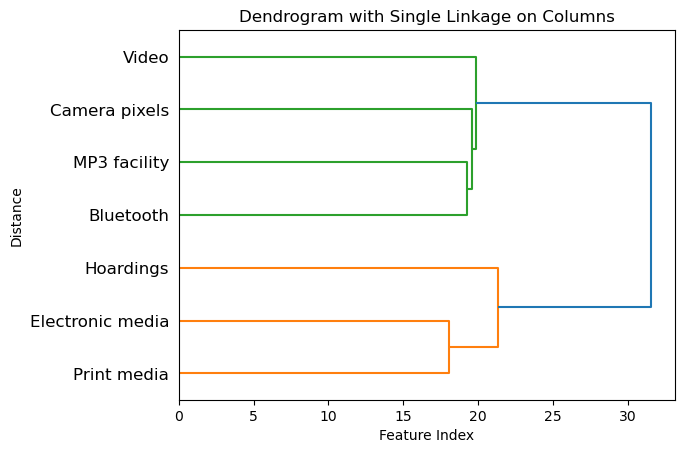

```python
from scipy.cluster.hierarchy import linkage, dendrogram

# Assuming 'data_HS_Factor' is your data matrix
# Transpose the data matrix to cluster on columns
data_transposed = data_HS_Factor_Final.T

# Perform hierarchical clustering with single linkage
linkage_matrix = linkage(data_transposed, method='single')

# Create a dendrogram
#dendrogram(linkage_matrix, orientation='top', labels=data_HS_Factor.columns, distance_sort='descending', show_leaf_counts=True)

# Create a dendrogram with transposed orientation
dendrogram(linkage_matrix, orientation='right', labels=data_HS_Factor_Final.columns
           , distance_sort='descending', show_leaf_counts=True)

# Add labels and title
plt.xlabel('Feature Index')
plt.ylabel('Distance')
plt.title('Dendrogram with Single Linkage on Columns')

# Show the plot
plt.show()
```

**From the Dendrogram, it is clearly evident that there are two groups of variables, signifying different aspects. This suggest that there are correlations between variables as well as the number of factors that can be extracted.**

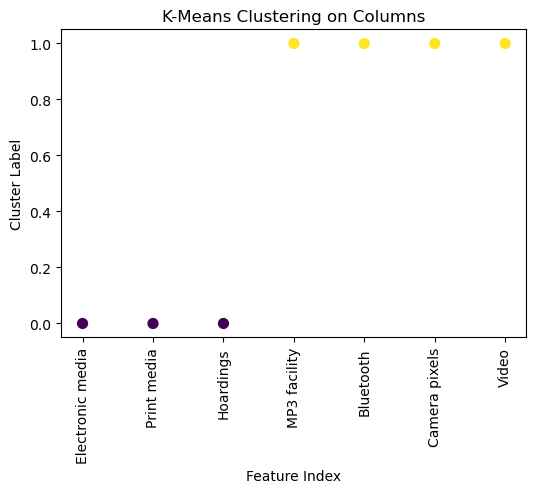

```python
import matplotlib.pyplot as plt
from sklearn.cluster import KMeans

# Assuming 'data_HS_Factor' is your data matrix
# Transpose the data matrix to cluster on columns
data_transposed = data_HS_Factor_Final.T

# Specify the number of clusters (k)
num_clusters = 2  # You can adjust this based on your requirements

# Perform k-means clustering
kmeans = KMeans(n_clusters=num_clusters, random_state=42)
cluster_labels = kmeans.fit_predict(data_transposed)

# Visualize the results
plt.figure(figsize=(6, 4))
plt.scatter(data_transposed.index, cluster_labels, c=cluster_labels, cmap='viridis', marker='o', s=50)
plt.title('K-Means Clustering on Columns')
plt.xticks(rotation=90)
plt.xlabel('Feature Index')
plt.ylabel('Cluster Label')
plt.show()
```

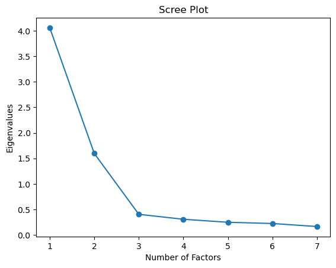

```python
import matplotlib.pyplot as plt
import numpy as np
from factor_analyzer import FactorAnalyzer

# Assuming 'data_HS_Factor' is your DataFrame
# Specify a range of factor numbers
num_factors_range = range(1, len(data_HS_Factor_Final.columns) + 1)

# Create an empty list to store eigenvalues
eigenvalues = []

# Iterate over different numbers of factors
for n_factors in num_factors_range:
    fa = FactorAnalyzer(n_factors, method='principal', rotation='varimax')
    fa.fit(data_HS_Factor_Final)
    eigenvalues.append(fa.get_eigenvalues()[0][n_factors - 1])  # Extract the eigenvalue for the specified number of factors

# Plot the scree plot
plt.plot(num_factors_range, eigenvalues, marker='o')
plt.title('Scree Plot')
plt.xlabel('Number of Factors')
plt.ylabel('Eigenvalues')
plt.show()
```

### 3.2.7 Extraction of Factors

Factor analysis consists of selecting the method of extracting the components, the number of components to be extracted, and the method of rotation for interpretation of the factors. We have selected the Principal Component Method of extraction and the varimax method of rotation. The number of factors extracted is based on eigenvalue more than one rule. This has resulted in several tables and we consider them one by one.

### 3.2.8 Communalities Table:

This table gives us the proportion of variance explained by the underlying factors. After extraction some of the factors are discarded and so some information is lost. The amount of variance in each variable that can be explained by the retained factors is represented by the communalities after extraction.

```python
import pandas as pd
from factor_analyzer import FactorAnalyzer

# Assuming 'data_HS_Factor' is your DataFrame
# Specify the number of factors
n_factors = 2

#The rotation must be one of the following:
#['varimax', 'oblimax', 'quartimax', 'equamax', 'geomin_ort', 'promax', 'oblimin', 'quartimin', 'geomin_obl', None]
# Defaults to ‘promax’.

# Create a FactorAnalyzer object
fa_woer = FactorAnalyzer(len(data_HS_Factor_Final.columns),method='principal',rotation=None) #without extracation and rotation
fa_wer  = FactorAnalyzer(n_factors,method='principal', rotation='varimax')

# Fit the factor model to your data
fa_woer.fit(data_HS_Factor_Final)
fa_wer.fit(data_HS_Factor_Final)

# Get the variable names
features = data_HS_Factor_Final.columns

# Get initial communalities
communalities_without_extraction_rotation = fa_woer.get_communalities()

# Get extracted communalities
communalities_with_extraction_rotation = fa_wer.get_communalities()

# Create a DataFrame with feature, initial communality, and extracted communality
communalities_table = pd.DataFrame({    'Feature': features,
                                    'Communalities (Initial)': communalities_without_extraction_rotation,
                                    'Communalities (With Extraction and Rotation)': communalities_with_extraction_rotation,
                                   })

# Display the communalities table
# print('\n',features)
# print('\n',communalities_without_rotation)
# print('\n',communalities_with_rotation,'\n')

communalities_table.style.applymap(highlight_cell)
```

|  | Feature | Communalities (Initial) | Communalities (With Extraction and Rotation) |
| --- | --- | --- | --- |
| 0 | Electronic media | 1.000000 | 0.806702 |
| 1 | Print media | 1.000000 | 0.818329 |
| 2 | Hoardings | 1.000000 | 0.743834 |
| 3 | MP3 facility | 1.000000 | 0.805195 |
| 4 | Bluetooth | 1.000000 | 0.848188 |
| 5 | Camera pixels | 1.000000 | 0.833526 |
| 6 | Video | 1.000000 | 0.797564 |

**From the table we note that all the variables have their communalities above 0.744. Remember, we have already eliminated the unimportant variables from the analysis.**

### 3.2.9 Total Variance Explained Table:

This table gives eigenvalues, variance explained, and cumulative variance explained for your factor solution. The first panel gives values based on initial eigenvalues. For the initial solution, there are as many components or factors as there are variables. The ”Total” column gives the amount of variance in the observed variables accounted for by each component or factor. The ”% of Variance” column gives the percent of variance accounted for by each specific factor or component, relative to the total variance in all the variables. The ”Cumulative %” column gives the percent of variance accounted for by all factors or components up to and including the current one. For instance the Cumulative % for the second factor is the sum of the % of Variance for the first and second factors. In a good factor analysis, there are a few factors that explain a lot of the variance and the rest of the factors explain relatively small amounts of variance. The Extraction Sums of Squared Loadings group gives information regarding the extracted factors or components. For principal components extraction, these values will be the same as those reported under Initial Eigenvalues. For other extraction methods, these values will generally be smaller than the initial values, due to errors in measurements. The variance accounted for by rotated factors or components may be different from those reported for the extraction but the Cumulative % for the set of factors or components will always be the same.

```python
import pandas as pd
from factor_analyzer import FactorAnalyzer

# Assuming 'data_HS_Factor' is your DataFrame
# Specify the number of factors
n_factors = 2

# Create a FactorAnalyzer object
fa = FactorAnalyzer(n_factors, method='principal', rotation='varimax')

# Fit the factor model to your data
fa.fit(data_HS_Factor_Final)

# Get the explained variance
explained_variance = fa.get_factor_variance()

# Get additional information
initial_eigenvalues = fa.get_eigenvalues()[0]
percentage_of_variance = initial_eigenvalues / sum(initial_eigenvalues) * 100
cumulative_percentage_of_variance = percentage_of_variance.cumsum()

rotation_sums_squared_loadings = fa.get_factor_variance()[0]
percentage_of_rotation_sums_squared_loadings = fa.get_factor_variance()[1]*100
cumulative_percentage_of_rotation_sums_squared_loadings = fa.get_factor_variance()[2]*100

intial_variance_table = pd.DataFrame({
    'Component': [f'{i + 1}' for i in range(len(data_HS_Factor_Final.columns))],
    'Initial Eigenvalues': initial_eigenvalues,
    'Initial Eigenvalues (% of Variance)': percentage_of_variance,
    'Initial Eigenvalues (%Cumulative of Variance)': cumulative_percentage_of_variance,

})

factor_variance_table = pd.DataFrame({
    'Component': [f'{i + 1}' for i in range(n_factors)],
    'Rotation SS Loadings': rotation_sums_squared_loadings,
    'Rotation SS Loadings (% of Variance)': percentage_of_rotation_sums_squared_loadings,
    'Rotation SS Loadings (Cumulative of Variance)': cumulative_percentage_of_rotation_sums_squared_loadings
})

# Combine both dataframes
combined_table = pd.merge(intial_variance_table, factor_variance_table, on='Component', how='left')

# Display the combined table
print("Total Variance Explained Table:")
round(combined_table,3)
```

```
Total Variance Explained Table:
```

|  | Component | Initial Eigenvalues | Initial Eigenvalues (% of Variance) | Initial Eigenvalues (%Cumulative of Variance) | Rotation SS Loadings | Rotation SS Loadings (% of Variance) | Rotation SS Loadings (Cumulative of Variance) |
| --- | --- | --- | --- | --- | --- | --- | --- |
| 0 | 1 | 4.058 | 57.967 | 57.967 | 3.221 | 46.021 | 46.021 |
| 1 | 2 | 1.596 | 22.795 | 80.762 | 2.432 | 34.741 | 80.762 |
| 2 | 3 | 0.404 | 5.768 | 86.530 | NaN | NaN | NaN |
| 3 | 4 | 0.307 | 4.385 | 90.916 | NaN | NaN | NaN |
| 4 | 5 | 0.248 | 3.538 | 94.453 | NaN | NaN | NaN |
| 5 | 6 | 0.224 | 3.200 | 97.653 | NaN | NaN | NaN |
| 6 | 7 | 0.164 | 2.347 | 100.000 | NaN | NaN | NaN |

**From the table we note that there are two eigenvalues, namely, 4.058, 1.596 whose values exceed 1. These factors account for 80.762% of the total variation. Individually, the first factor explains 57.967%, and the second factor explains 22.795% of the total variation.**

### 3.2.10 Number of Factors To Be Extracted

There are quite a number guiding rules to determine the number of factors to be extracted. Some of the popular criteria are

- Eigenvalue greater than one rule
- Scree Plot
- Total Variance Explained

### 3.2.11 Components Matrix

The Component Matrix gives the estimated factor loadings. The elements of this matrix describe the covariances or the correlations between the manifest variables and the latent common factors depending on whether the covariance matrix or correlation matrix is involved in the analysis. The sum of squares of the row elements of Component Matrix gives the communality of the corresponding variable. Using which we can estimate the specific variances of the manifest variables. Similarly, the sum of squares of the column elements of Component Matrix gives the eigenvalues of the covariance/correlation matrix. These values help in the computation of the proportion of variance explained by each factor. The method of estimation used to get the Component Matrix is the Principal Component method of estimation. This is referred to as unrotated factor solution.

```python
import pandas as pd
from factor_analyzer import FactorAnalyzer

# Assuming 'data_HS_Factor' is your DataFrame
# Specify the number of factors
n_factors = 2

# Create a FactorAnalyzer object
fa = FactorAnalyzer(n_factors,method='principal', rotation=None)

# Fit the factor model to your data
fa.fit(data_HS_Factor_Final)

# Get the component matrix
component_matrix = pd.DataFrame(fa.loadings_, index=data_HS_Factor_Final.columns
                                , columns=[f'Factor {i + 1}' for i in range(n_factors)])

# Display the component matrix
print("Component Matrix:")
component_matrix.style.applymap(highlight_cell)
```

```
Component Matrix:
```

| Feature | Factor 1 | Factor 2 |
| --- | --- | --- |
| Electronic media | 0.674567 | 0.593010 |
| Print media | 0.687301 | 0.588172 |
| Hoardings | 0.585451 | 0.633310 |
| MP3 facility | 0.833684 | -0.331914 |
| Bluetooth | 0.838281 | -0.381408 |
| Camera pixels | 0.847734 | -0.338931 |
| Video | 0.819231 | -0.355561 |

We now try to interpret the factor solution by examining the elements of this Component Matrix. From this matrix we observe that except for one element all the rest of the elements are loaded on the first factor. However, common sense says that they does not belong to a single category. This makes interpretation of the factors difficult. To facilitate the interpretation of the factors, we consider the varimax rotation. This has resulted in the following rotated solution.

### 3.2.12 Rotated Component Matrix

From this Rotated Component Matrix, we note that all the variables have got partitioned into two mutually exclusive groups and are clearly interpretable. The first group of variables signifies the **features** of the mobile and the second group can be called a **media factor**. This explains how the rotation of initial factor solution is useful in the interpretation of factors.

```python
import pandas as pd
from factor_analyzer import FactorAnalyzer

# Assuming 'data_HS_Factor' is your DataFrame
# Specify the number of factors
n_factors = 2

# Create a FactorAnalyzer object
fa = FactorAnalyzer(n_factors, method='principal', rotation='varimax')

# Fit the factor model to your data
fa.fit(data_HS_Factor_Final)

# Get the component matrix
component_matrix = pd.DataFrame(fa.loadings_, index=data_HS_Factor_Final.columns
                                , columns=[f'Factor {i + 1}' for i in range(n_factors)])

# Display the component matrix
print("Rotated Component Matrix:")
component_matrix.style.applymap(highlight_cell)
```

```
Rotated Component Matrix:
```

| Feature | Factor 1 | Factor 2 |
| --- | --- | --- |
| Electronic media | 0.202574 | 0.875023 |
| Print media | 0.215742 | 0.878513 |
| Hoardings | 0.106670 | 0.855836 |
| MP3 facility | 0.870908 | 0.216135 |
| Bluetooth | 0.903489 | 0.178595 |
| Camera pixels | 0.886415 | 0.218622 |
| Video | 0.872945 | 0.188497 |

# Chapter 4

# Analysis of Usage of Mobile Phones

## 4.1 Introduction

In this section we attempt to study our second objective, namely What for students are using mobiles? To study this, we have formulated a question with 13 variables and we felt that these variables are useful in order to study the above mentioned objective. A student may using a mobile, because all his friends are using, or he is feeling secured in case of emergency, or he may be using to communicate with his family and friends. To measure the usage of a mobile we have formulated the following questions.

- I use cell phone because all my friends uses (All my friends use).
- I look old fashioned without it (Old fashioned ).
- It brings me prestige in my environment (Prestige).
- I feel secured in case of emergency (Secure).
- I like showing the features of my phone to people around me(Show-off).
- It matches my lifestyle (Life style).
- I need it for urgent communication(Communication).
- I make use of most of the facilities available with my phone(Facilities).
- It makes my life easier(Life easier).
- Mostly use to call friends and family (Call Friends and Family).
- Mostly use to SMS (Mostly use SMS).
- Mostly use to listen music / to watch videos (Music or Videos).
- Mostly use for games (Games).

We now consider factor analysis to analyze the data for these questions. Principal Component Method is used to extract the factors. Eigenvalue more than one rule is used to fix the number of factors to be extracted. we rotated the factors using the varimax rotation.

```python
Usage_Columns = ['All my friends use',
                                'Old fashioned',
                                'Prestige',
                                'Secure',
                                'Show-off',
                                'Life style',
                                'Communication',
                                'Facilities',
                                'Life easier',
                                'Call Friends and Family',
                                'Mostly use SMS',
                                'Music or Videos',
                                'Games'
                               ]

data_Usage_Factor = data2[Usage_Columns].dropna()
data_Usage_Factor.head()
```

| Feature | All my friends use | Old fashioned | Prestige | Secure | Show-off | Life style | Communication | Facilities | Life easier | Call Friends and Family | Mostly use SMS | Music or Videos | Games |
| --- | --- | --- | --- | --- | --- | --- | --- | --- | --- | --- | --- | --- | --- |
| 0 | 3 | 2 | 2 | 4 | 3 | 4 | 4 | 4 | 4 | 4.0 | 2 | 3 | 2 |
| 1 | 5 | 1 | 3 | 5 | 2 | 5 | 5 | 3 | 4 | 5.0 | 3 | 2 | 3 |
| 2 | 4 | 2 | 2 | 5 | 2 | 2 | 5 | 4 | 4 | 5.0 | 4 | 4 | 3 |
| 3 | 4 | 4 | 3 | 4 | 4 | 2 | 4 | 4 | 4 | 4.0 | 4 | 5 | 4 |
| 4 | 4 | 4 | 4 | 4 | 4 | 5 | 5 | 5 | 5 | 5.0 | 4 | 5 | 5 |

```python
data_Usage_Factor['Call Friends and Family'] = data_Usage_Factor['Call Friends and Family'].astype(int)
data_Usage_Factor.head()
```

| Feature | All my friends use | Old fashioned | Prestige | Secure | Show-off | Life style | Communication | Facilities | Life easier | Call Friends and Family | Mostly use SMS | Music or Videos | Games |
| --- | --- | --- | --- | --- | --- | --- | --- | --- | --- | --- | --- | --- | --- |
| 0 | 3 | 2 | 2 | 4 | 3 | 4 | 4 | 4 | 4 | 4 | 2 | 3 | 2 |
| 1 | 5 | 1 | 3 | 5 | 2 | 5 | 5 | 3 | 4 | 5 | 3 | 2 | 3 |
| 2 | 4 | 2 | 2 | 5 | 2 | 2 | 5 | 4 | 4 | 5 | 4 | 4 | 3 |
| 3 | 4 | 4 | 3 | 4 | 4 | 2 | 4 | 4 | 4 | 4 | 4 | 5 | 4 |
| 4 | 4 | 4 | 4 | 4 | 4 | 5 | 5 | 5 | 5 | 5 | 4 | 5 | 5 |

```python
round(data_Usage_Factor.corr(),3).style.applymap(highlight_cell)
```

| Feature | All my friends use | Old fashioned | Prestige | Secure | Show-off | Life style | Communication | Facilities | Life easier | Call Friends and Family | Mostly use SMS | Music or Videos | Games |
| --- | --- | --- | --- | --- | --- | --- | --- | --- | --- | --- | --- | --- | --- |
| All my friends use | 1.000000 | 0.499000 | 0.473000 | -0.001000 | 0.372000 | 0.303000 | -0.090000 | 0.115000 | 0.126000 | 0.055000 | 0.176000 | 0.153000 | 0.148000 |
| Old fashioned | 0.499000 | 1.000000 | 0.498000 | -0.002000 | 0.328000 | 0.261000 | -0.013000 | 0.138000 | 0.135000 | -0.001000 | 0.170000 | 0.176000 | 0.165000 |
| Prestige | 0.473000 | 0.498000 | 1.000000 | 0.018000 | 0.490000 | 0.406000 | -0.079000 | 0.098000 | 0.209000 | 0.008000 | 0.217000 | 0.261000 | 0.247000 |
| Secure | -0.001000 | -0.002000 | 0.018000 | 1.000000 | 0.099000 | 0.139000 | 0.436000 | 0.216000 | 0.265000 | 0.363000 | 0.180000 | 0.172000 | 0.155000 |
| Show-off | 0.372000 | 0.328000 | 0.490000 | 0.099000 | 1.000000 | 0.584000 | 0.052000 | 0.225000 | 0.220000 | 0.074000 | 0.275000 | 0.410000 | 0.329000 |
| Life style | 0.303000 | 0.261000 | 0.406000 | 0.139000 | 0.584000 | 1.000000 | 0.088000 | 0.370000 | 0.418000 | 0.228000 | 0.282000 | 0.398000 | 0.375000 |
| Communication | -0.090000 | -0.013000 | -0.079000 | 0.436000 | 0.052000 | 0.088000 | 1.000000 | 0.301000 | 0.343000 | 0.383000 | 0.132000 | 0.074000 | 0.082000 |
| Facilities | 0.115000 | 0.138000 | 0.098000 | 0.216000 | 0.225000 | 0.370000 | 0.301000 | 1.000000 | 0.497000 | 0.312000 | 0.284000 | 0.322000 | 0.210000 |
| Life easier | 0.126000 | 0.135000 | 0.209000 | 0.265000 | 0.220000 | 0.418000 | 0.343000 | 0.497000 | 1.000000 | 0.347000 | 0.279000 | 0.390000 | 0.290000 |
| Call Friends and Family | 0.055000 | -0.001000 | 0.008000 | 0.363000 | 0.074000 | 0.228000 | 0.383000 | 0.312000 | 0.347000 | 1.000000 | 0.192000 | 0.227000 | 0.179000 |
| Mostly use SMS | 0.176000 | 0.170000 | 0.217000 | 0.180000 | 0.275000 | 0.282000 | 0.132000 | 0.284000 | 0.279000 | 0.192000 | 1.000000 | 0.430000 | 0.359000 |
| Music or Videos | 0.153000 | 0.176000 | 0.261000 | 0.172000 | 0.410000 | 0.398000 | 0.074000 | 0.322000 | 0.390000 | 0.227000 | 0.430000 | 1.000000 | 0.543000 |
| Games | 0.148000 | 0.165000 | 0.247000 | 0.155000 | 0.329000 | 0.375000 | 0.082000 | 0.210000 | 0.290000 | 0.179000 | 0.359000 | 0.543000 | 1.000000 |

```python
import pandas as pd
import numpy as np
from scipy.stats import pearsonr

# Assuming 'df' is your DataFrame
# Create a correlation matrix
correlation_matrix = data_Usage_Factor.corr()

# Create an empty DataFrame for p-values
p_values_matrix = pd.DataFrame(np.zeros_like(correlation_matrix)
                               , columns=correlation_matrix.columns, index=correlation_matrix.index)

# Calculate p-values for each pair of variables
for i in range(len(correlation_matrix.columns)):
    for j in range(i+1, len(correlation_matrix.columns)):
        corr, p_value = pearsonr(data_Usage_Factor[correlation_matrix.columns[i]]
                                 , data_Usage_Factor[correlation_matrix.columns[j]])
        p_values_matrix.iloc[i, j] = p_value
        p_values_matrix.iloc[j, i] = p_value

# Print the correlation matrix
print("Correlation Matrix:")
display(correlation_matrix.style.applymap(highlight_cell))

# Print the p-values matrix
print("\nP-Values Matrix:")
display(round(p_values_matrix,3))
```

```
Correlation Matrix:
```

| Feature | All my friends use | Old fashioned | Prestige | Secure | Show-off | Life style | Communication | Facilities | Life easier | Call Friends and Family | Mostly use SMS | Music or Videos | Games |
| --- | --- | --- | --- | --- | --- | --- | --- | --- | --- | --- | --- | --- | --- |
| All my friends use | 1.000000 | 0.498746 | 0.472517 | -0.001349 | 0.371677 | 0.303350 | -0.089704 | 0.114547 | 0.126377 | 0.055044 | 0.175527 | 0.152900 | 0.147724 |
| Old fashioned | 0.498746 | 1.000000 | 0.498092 | -0.001736 | 0.327575 | 0.260526 | -0.012605 | 0.138282 | 0.135351 | -0.000598 | 0.170099 | 0.175803 | 0.164977 |
| Prestige | 0.472517 | 0.498092 | 1.000000 | 0.017706 | 0.489601 | 0.405839 | -0.078796 | 0.098400 | 0.209075 | 0.007512 | 0.217011 | 0.260811 | 0.246758 |
| Secure | -0.001349 | -0.001736 | 0.017706 | 1.000000 | 0.099391 | 0.138603 | 0.435566 | 0.216036 | 0.265256 | 0.362848 | 0.179875 | 0.172270 | 0.154889 |
| Show-off | 0.371677 | 0.327575 | 0.489601 | 0.099391 | 1.000000 | 0.583700 | 0.051842 | 0.225049 | 0.220372 | 0.074165 | 0.274754 | 0.409534 | 0.329304 |
| Life style | 0.303350 | 0.260526 | 0.405839 | 0.138603 | 0.583700 | 1.000000 | 0.087973 | 0.369733 | 0.417797 | 0.228042 | 0.282142 | 0.398226 | 0.374845 |
| Communication | -0.089704 | -0.012605 | -0.078796 | 0.435566 | 0.051842 | 0.087973 | 1.000000 | 0.301058 | 0.342671 | 0.382600 | 0.132334 | 0.074264 | 0.081835 |
| Facilities | 0.114547 | 0.138282 | 0.098400 | 0.216036 | 0.225049 | 0.369733 | 0.301058 | 1.000000 | 0.496751 | 0.311780 | 0.283562 | 0.321743 | 0.210002 |
| Life easier | 0.126377 | 0.135351 | 0.209075 | 0.265256 | 0.220372 | 0.417797 | 0.342671 | 0.496751 | 1.000000 | 0.346972 | 0.279440 | 0.389631 | 0.289965 |
| Call Friends and Family | 0.055044 | -0.000598 | 0.007512 | 0.362848 | 0.074165 | 0.228042 | 0.382600 | 0.311780 | 0.346972 | 1.000000 | 0.192116 | 0.227030 | 0.178823 |
| Mostly use SMS | 0.175527 | 0.170099 | 0.217011 | 0.179875 | 0.274754 | 0.282142 | 0.132334 | 0.283562 | 0.279440 | 0.192116 | 1.000000 | 0.430105 | 0.359471 |
| Music or Videos | 0.152900 | 0.175803 | 0.260811 | 0.172270 | 0.409534 | 0.398226 | 0.074264 | 0.321743 | 0.389631 | 0.227030 | 0.430105 | 1.000000 | 0.543107 |
| Games | 0.147724 | 0.164977 | 0.246758 | 0.154889 | 0.329304 | 0.374845 | 0.081835 | 0.210002 | 0.289965 | 0.178823 | 0.359471 | 0.543107 | 1.000000 |

```
P-Values Matrix:
```

| Feature | All my friends use | Old fashioned | Prestige | Secure | Show-off | Life style | Communication | Facilities | Life easier | Call Friends and Family | Mostly use SMS | Music or Videos | Games |
| --- | --- | --- | --- | --- | --- | --- | --- | --- | --- | --- | --- | --- | --- |
| All my friends use | 0.000 | 0.000 | 0.000 | 0.975 | 0.000 | 0.000 | 0.040 | 0.009 | 0.004 | 0.208 | 0.000 | 0.000 | 0.001 |
| Old fashioned | 0.000 | 0.000 | 0.000 | 0.968 | 0.000 | 0.000 | 0.773 | 0.001 | 0.002 | 0.989 | 0.000 | 0.000 | 0.000 |
| Prestige | 0.000 | 0.000 | 0.000 | 0.685 | 0.000 | 0.000 | 0.071 | 0.024 | 0.000 | 0.864 | 0.000 | 0.000 | 0.000 |
| Secure | 0.975 | 0.968 | 0.685 | 0.000 | 0.023 | 0.001 | 0.000 | 0.000 | 0.000 | 0.000 | 0.000 | 0.000 | 0.000 |
| Show-off | 0.000 | 0.000 | 0.000 | 0.023 | 0.000 | 0.000 | 0.235 | 0.000 | 0.000 | 0.089 | 0.000 | 0.000 | 0.000 |
| Life style | 0.000 | 0.000 | 0.000 | 0.001 | 0.000 | 0.000 | 0.044 | 0.000 | 0.000 | 0.000 | 0.000 | 0.000 | 0.000 |
| Communication | 0.040 | 0.773 | 0.071 | 0.000 | 0.235 | 0.044 | 0.000 | 0.000 | 0.000 | 0.000 | 0.002 | 0.089 | 0.061 |
| Facilities | 0.009 | 0.001 | 0.024 | 0.000 | 0.000 | 0.000 | 0.000 | 0.000 | 0.000 | 0.000 | 0.000 | 0.000 | 0.000 |
| Life easier | 0.004 | 0.002 | 0.000 | 0.000 | 0.000 | 0.000 | 0.000 | 0.000 | 0.000 | 0.000 | 0.000 | 0.000 | 0.000 |
| Call Friends and Family | 0.208 | 0.989 | 0.864 | 0.000 | 0.089 | 0.000 | 0.000 | 0.000 | 0.000 | 0.000 | 0.000 | 0.000 | 0.000 |
| Mostly use SMS | 0.000 | 0.000 | 0.000 | 0.000 | 0.000 | 0.000 | 0.002 | 0.000 | 0.000 | 0.000 | 0.000 | 0.000 | 0.000 |
| Music or Videos | 0.000 | 0.000 | 0.000 | 0.000 | 0.000 | 0.000 | 0.089 | 0.000 | 0.000 | 0.000 | 0.000 | 0.000 | 0.000 |
| Games | 0.001 | 0.000 | 0.000 | 0.000 | 0.000 | 0.000 | 0.061 | 0.000 | 0.000 | 0.000 | 0.000 | 0.000 | 0.000 |

```python
import pandas as pd
import numpy as np
from factor_analyzer import FactorAnalyzer
from factor_analyzer.factor_analyzer import calculate_kmo
from factor_analyzer.factor_analyzer import calculate_bartlett_sphericity

# Assuming 'data_HS_Factor' is your DataFrame
# Specify the number of factors
n_factors = 10

# Initialize FactorAnalyzer
fa = FactorAnalyzer(n_factors, rotation=None)

# Fit the model
fa.fit(data_Usage_Factor)

# Obtain the factor loadings
factor_loadings = pd.DataFrame(fa.loadings_, index=data_Usage_Factor.columns)

# Calculate Kaiser-Meyer-Olkin (KMO) Measure of Sampling Adequacy

kmo_per_variable, kmo_total = calculate_kmo(data_Usage_Factor)

# Print the KMO values
print("Kaiser-Meyer-Olkin (KMO) Measure of Sampling Adequacy per variable:")
print(kmo_per_variable)
print("\nKaiser-Meyer-Olkin (KMO) Measure of Sampling Adequacy (Total):", kmo_total)

chi2_statistic,p_value = calculate_bartlett_sphericity(data_Usage_Factor)

# Print the test statistics
print("\nBartlett's Test of Sphericity:")
print(f"Chi-Square Statistic: {chi2_statistic}")
print(f"P-value: {p_value}")
```

```
Kaiser-Meyer-Olkin (KMO) Measure of Sampling Adequacy per variable:
[0.80430188 0.78637892 0.82539714 0.79300566 0.80462342 0.83527949
 0.69673044 0.84693816 0.82979813 0.82782272 0.90534089 0.8153543
 0.84438626]

Kaiser-Meyer-Olkin (KMO) Measure of Sampling Adequacy (Total): 0.8188382947514252

Bartlett's Test of Sphericity:
Chi-Square Statistic: 1950.3964695305046
P-value: 0.0
```

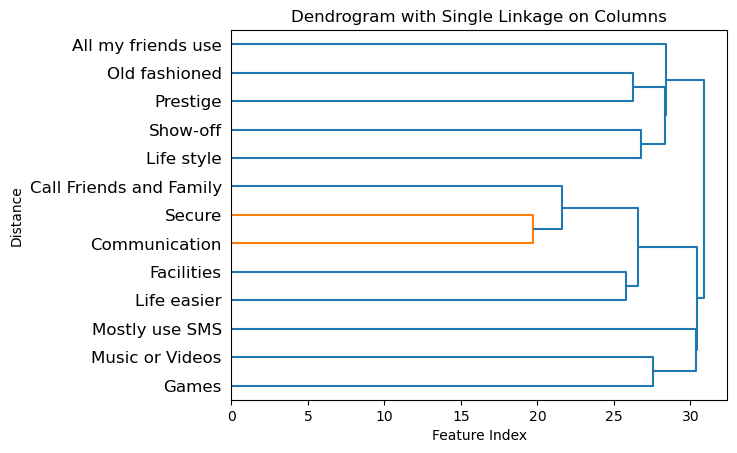

```python
from scipy.cluster.hierarchy import linkage, dendrogram

# Assuming 'data_HS_Factor' is your data matrix
# Transpose the data matrix to cluster on columns
data_transposed = data_Usage_Factor.T

# Perform hierarchical clustering with single linkage
linkage_matrix = linkage(data_transposed, method='single')

# Create a dendrogram
#dendrogram(linkage_matrix, orientation='top', labels=data_HS_Factor.columns, distance_sort='descending', show_leaf_counts=True)

# Create a dendrogram with transposed orientation
dendrogram(linkage_matrix, orientation='right', labels=data_Usage_Factor.columns
           , distance_sort='descending', show_leaf_counts=True)

# Add labels and title
plt.xlabel('Feature Index')
plt.ylabel('Distance')
plt.title('Dendrogram with Single Linkage on Columns')

# Show the plot
plt.show()
```

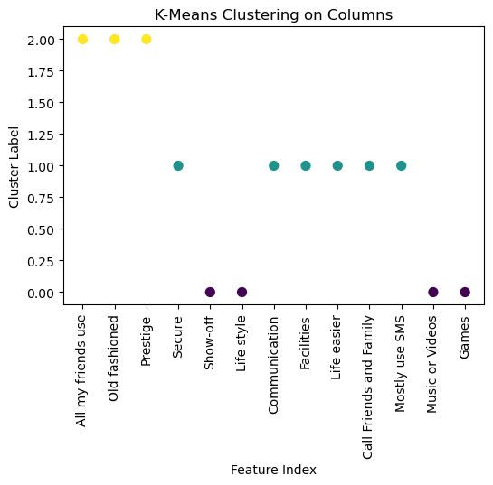

```python
import matplotlib.pyplot as plt
from sklearn.cluster import KMeans

# Assuming 'data_HS_Factor' is your data matrix
# Transpose the data matrix to cluster on columns
data_transposed = data_Usage_Factor.T

# Specify the number of clusters (k)
num_clusters = 3  # You can adjust this based on your requirements

# Perform k-means clustering
kmeans = KMeans(n_clusters=num_clusters, random_state=42)
cluster_labels = kmeans.fit_predict(data_transposed)

# Visualize the results
plt.figure(figsize=(6, 4))
plt.scatter(data_transposed.index, cluster_labels, c=cluster_labels, cmap='viridis', marker='o', s=50)
plt.title('K-Means Clustering on Columns')
plt.xticks(rotation=90)
plt.xlabel('Feature Index')
plt.ylabel('Cluster Label')
plt.show()
```

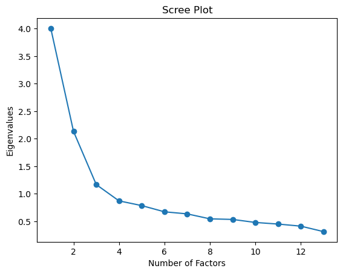

```python
import matplotlib.pyplot as plt
import numpy as np
from factor_analyzer import FactorAnalyzer

# Assuming 'data_HS_Factor' is your DataFrame
# Specify a range of factor numbers
num_factors_range = range(1, len(data_Usage_Factor.columns) + 1)

# Create an empty list to store eigenvalues
eigenvalues = []

# Iterate over different numbers of factors
for n_factors in num_factors_range:
    fa = FactorAnalyzer(n_factors, method='principal', rotation='varimax')
    fa.fit(data_Usage_Factor)
    eigenvalues.append(fa.get_eigenvalues()[0][n_factors - 1])  # Extract the eigenvalue for the specified number of factors

# Plot the scree plot
plt.plot(num_factors_range, eigenvalues, marker='o')
plt.title('Scree Plot')
plt.xlabel('Number of Factors')
plt.ylabel('Eigenvalues')
plt.show()
```

```python
import pandas as pd
from factor_analyzer import FactorAnalyzer

# Assuming 'data_HS_Factor' is your DataFrame
# Specify the number of factors
n_factors = 3

#The rotation must be one of the following:
#['varimax', 'oblimax', 'quartimax', 'equamax', 'geomin_ort', 'promax', 'oblimin', 'quartimin', 'geomin_obl', None]
# Defaults to ‘promax’.

# Create a FactorAnalyzer object
fa_woer = FactorAnalyzer(len(data_Usage_Factor.columns),method='principal',rotation=None) #without extracation and rotation
fa_wer  = FactorAnalyzer(n_factors,method='principal', rotation='varimax')

# Fit the factor model to your data
fa_woer.fit(data_Usage_Factor)
fa_wer.fit(data_Usage_Factor)

# Get the variable names
features = data_Usage_Factor.columns

# Get initial communalities
communalities_without_extraction_rotation = fa_woer.get_communalities()

# Get extracted communalities
communalities_with_extraction_rotation = fa_wer.get_communalities()

# Create a DataFrame with feature, initial communality, and extracted communality
communalities_table = pd.DataFrame({    'Feature': features,
                                    'Communalities (Initial)': communalities_without_extraction_rotation,
                                    'Communalities (With Extraction and Rotation)': communalities_with_extraction_rotation,
                                   })

# Display the communalities table
# print('\n',features)
# print('\n',communalities_without_rotation)
# print('\n',communalities_with_rotation,'\n')

communalities_table.style.applymap(highlight_cell)
```

|  | Feature | Communalities (Initial) | Communalities (With Extraction and Rotation) |
| --- | --- | --- | --- |
| 0 | All my friends use | 1.000000 | 0.633249 |
| 1 | Old fashioned | 1.000000 | 0.619626 |
| 2 | Prestige | 1.000000 | 0.645572 |
| 3 | Secure | 1.000000 | 0.477266 |
| 4 | Show-off | 1.000000 | 0.556583 |
| 5 | Life style | 1.000000 | 0.547260 |
| 6 | Communication | 1.000000 | 0.636375 |
| 7 | Facilities | 1.000000 | 0.443585 |
| 8 | Life easier | 1.000000 | 0.525172 |
| 9 | Call Friends and Family | 1.000000 | 0.500557 |
| 10 | Mostly use SMS | 1.000000 | 0.419769 |
| 11 | Music or Videos | 1.000000 | 0.693950 |
| 12 | Games | 1.000000 | 0.605794 |

```python
import pandas as pd
from factor_analyzer import FactorAnalyzer

# Assuming 'data_HS_Factor' is your DataFrame
# Specify the number of factors
n_factors = 3

# Create a FactorAnalyzer object
fa = FactorAnalyzer(n_factors, method='principal', rotation='varimax')

# Fit the factor model to your data
fa.fit(data_Usage_Factor)

# Get the explained variance
explained_variance = fa.get_factor_variance()

# Get additional information
initial_eigenvalues = fa.get_eigenvalues()[0]
percentage_of_variance = initial_eigenvalues / sum(initial_eigenvalues) * 100
cumulative_percentage_of_variance = percentage_of_variance.cumsum()

rotation_sums_squared_loadings = fa.get_factor_variance()[0]
percentage_of_rotation_sums_squared_loadings = fa.get_factor_variance()[1]*100
cumulative_percentage_of_rotation_sums_squared_loadings = fa.get_factor_variance()[2]*100

intial_variance_table = pd.DataFrame({
    'Component': [f'{i + 1}' for i in range(len(data_Usage_Factor.columns))],
    'Initial Eigenvalues': initial_eigenvalues,
    'Initial Eigenvalues (% of Variance)': percentage_of_variance,
    'Initial Eigenvalues (%Cumulative of Variance)': cumulative_percentage_of_variance,

})

factor_variance_table = pd.DataFrame({
    'Component': [f'{i + 1}' for i in range(n_factors)],
    'Rotation SS Loadings': rotation_sums_squared_loadings,
    'Rotation SS Loadings (% of Variance)': percentage_of_rotation_sums_squared_loadings,
    'Rotation SS Loadings (Cumulative of Variance)': cumulative_percentage_of_rotation_sums_squared_loadings
})

# Combine both dataframes
combined_table = pd.merge(intial_variance_table, factor_variance_table, on='Component', how='left')

# Display the combined table
print("Total Variance Explained Table:")
round(combined_table,3)
```

```
Total Variance Explained Table:
```

|  | Component | Initial Eigenvalues | Initial Eigenvalues (% of Variance) | Initial Eigenvalues (%Cumulative of Variance) | Rotation SS Loadings | Rotation SS Loadings (% of Variance) | Rotation SS Loadings (Cumulative of Variance) |
| --- | --- | --- | --- | --- | --- | --- | --- |
| 0 | 1 | 4.005 | 30.805 | 30.805 | 2.521 | 19.395 | 19.395 |
| 1 | 2 | 2.133 | 16.405 | 47.210 | 2.336 | 17.971 | 37.366 |
| 2 | 3 | 1.167 | 8.981 | 56.190 | 2.447 | 18.825 | 56.190 |
| 3 | 4 | 0.871 | 6.701 | 62.891 | NaN | NaN | NaN |
| 4 | 5 | 0.785 | 6.040 | 68.932 | NaN | NaN | NaN |
| 5 | 6 | 0.673 | 5.173 | 74.105 | NaN | NaN | NaN |
| 6 | 7 | 0.635 | 4.883 | 78.988 | NaN | NaN | NaN |
| 7 | 8 | 0.545 | 4.189 | 83.178 | NaN | NaN | NaN |
| 8 | 9 | 0.534 | 4.107 | 87.285 | NaN | NaN | NaN |
| 9 | 10 | 0.479 | 3.684 | 90.969 | NaN | NaN | NaN |
| 10 | 11 | 0.450 | 3.459 | 94.428 | NaN | NaN | NaN |
| 11 | 12 | 0.412 | 3.168 | 97.596 | NaN | NaN | NaN |
| 12 | 13 | 0.313 | 2.404 | 100.000 | NaN | NaN | NaN |

```python
import pandas as pd
from factor_analyzer import FactorAnalyzer

# Assuming 'data_HS_Factor' is your DataFrame
# Specify the number of factors
n_factors = 3

# Create a FactorAnalyzer object
fa = FactorAnalyzer(n_factors,method='principal', rotation=None)

# Fit the factor model to your data
fa.fit(data_Usage_Factor)

# Get the component matrix
component_matrix = pd.DataFrame(fa.loadings_, index=data_Usage_Factor.columns
                                , columns=[f'Factor {i + 1}' for i in range(n_factors)])

# Display the component matrix
print("Component Matrix:")
component_matrix.style.applymap(highlight_cell)
```

```
Component Matrix:
```

| Feature | Factor 1 | Factor 2 | Factor 3 |
| --- | --- | --- | --- |
| All my friends use | 0.467659 | -0.515935 | 0.385169 |
| Old fashioned | 0.466294 | -0.492869 | 0.399093 |
| Prestige | 0.566510 | -0.533434 | 0.200217 |
| Secure | 0.353252 | 0.530536 | 0.266479 |
| Show-off | 0.669946 | -0.326937 | -0.029458 |
| Life style | 0.728591 | -0.120073 | -0.044685 |
| Communication | 0.294663 | 0.646400 | 0.362927 |
| Facilities | 0.570056 | 0.336049 | 0.075446 |
| Life easier | 0.637243 | 0.340172 | 0.058111 |
| Call Friends and Family | 0.418323 | 0.532059 | 0.206095 |
| Mostly use SMS | 0.567913 | 0.070017 | -0.303878 |
| Music or Videos | 0.681252 | 0.041663 | -0.477609 |
| Games | 0.603001 | 0.004764 | -0.492100 |

```python
import pandas as pd
from factor_analyzer import FactorAnalyzer

# Assuming 'data_HS_Factor' is your DataFrame
# Specify the number of factors
n_factors = 3

# Create a FactorAnalyzer object
fa = FactorAnalyzer(n_factors, method='principal', rotation='varimax')

# Fit the factor model to your data
fa.fit(data_Usage_Factor)

# Get the component matrix
component_matrix = pd.DataFrame(fa.loadings_, index=data_Usage_Factor.columns
                                , columns=[f'Factor {i + 1}' for i in range(n_factors)])

# Display the component matrix
print("Rotated Component Matrix:")
component_matrix.style.applymap(highlight_cell)
```

```
Rotated Component Matrix:
```

| Feature | Factor 1 | Factor 2 | Factor 3 |
| --- | --- | --- | --- |
| All my friends use | 0.037781 | 0.005005 | 0.794856 |
| Old fashioned | 0.027074 | 0.028202 | 0.786192 |
| Prestige | 0.239547 | -0.047079 | 0.765489 |
| Secure | 0.058331 | 0.688225 | -0.014505 |
| Show-off | 0.479761 | 0.051766 | 0.568975 |
| Life style | 0.534001 | 0.228504 | 0.458136 |
| Communication | -0.050344 | 0.792793 | -0.072939 |
| Facilities | 0.343642 | 0.554561 | 0.134003 |
| Life easier | 0.402638 | 0.581050 | 0.159486 |
| Call Friends and Family | 0.146955 | 0.691987 | -0.010705 |
| Mostly use SMS | 0.612902 | 0.178208 | 0.111182 |
| Music or Videos | 0.816421 | 0.129829 | 0.102714 |
| Games | 0.772360 | 0.058783 | 0.076146 |

### After going thru the above analysis we decide to keep only the below variables and run the Factor analysis again

```python
Usage_Columns_Final = ['All my friends use',
                'Old fashioned',
                'Prestige',
                'Secure',
                'Communication',
                'Call Friends and Family',
                'Mostly use SMS',
                'Music or Videos',
                'Games'
               ]

data_Usage_Factor_Final = data2[Usage_Columns_Final].dropna()
data_Usage_Factor_Final.head()
```

| Feature | All my friends use | Old fashioned | Prestige | Secure | Communication | Call Friends and Family | Mostly use SMS | Music or Videos | Games |
| --- | --- | --- | --- | --- | --- | --- | --- | --- | --- |
| 0 | 3 | 2 | 2 | 4 | 4 | 4.0 | 2 | 3 | 2 |
| 1 | 5 | 1 | 3 | 5 | 5 | 5.0 | 3 | 2 | 3 |
| 2 | 4 | 2 | 2 | 5 | 5 | 5.0 | 4 | 4 | 3 |
| 3 | 4 | 4 | 3 | 4 | 4 | 4.0 | 4 | 5 | 4 |
| 4 | 4 | 4 | 4 | 4 | 5 | 5.0 | 4 | 5 | 5 |

```python
data_Usage_Factor_Final['Call Friends and Family'] = data_Usage_Factor_Final['Call Friends and Family'].astype(int)
data_Usage_Factor_Final.head()
```

| Feature | All my friends use | Old fashioned | Prestige | Secure | Communication | Call Friends and Family | Mostly use SMS | Music or Videos | Games |
| --- | --- | --- | --- | --- | --- | --- | --- | --- | --- |
| 0 | 3 | 2 | 2 | 4 | 4 | 4 | 2 | 3 | 2 |
| 1 | 5 | 1 | 3 | 5 | 5 | 5 | 3 | 2 | 3 |
| 2 | 4 | 2 | 2 | 5 | 5 | 5 | 4 | 4 | 3 |
| 3 | 4 | 4 | 3 | 4 | 4 | 4 | 4 | 5 | 4 |
| 4 | 4 | 4 | 4 | 4 | 5 | 5 | 4 | 5 | 5 |

```python
data_Usage_Factor_Final.shape
```

```
(526, 9)
```

```python
round(data_Usage_Factor_Final.corr(),3).style.applymap(highlight_cell)
```

| Feature | All my friends use | Old fashioned | Prestige | Secure | Communication | Call Friends and Family | Mostly use SMS | Music or Videos | Games |
| --- | --- | --- | --- | --- | --- | --- | --- | --- | --- |
| All my friends use | 1.000000 | 0.499000 | 0.473000 | -0.001000 | -0.090000 | 0.055000 | 0.176000 | 0.153000 | 0.148000 |
| Old fashioned | 0.499000 | 1.000000 | 0.498000 | -0.002000 | -0.013000 | -0.001000 | 0.170000 | 0.176000 | 0.165000 |
| Prestige | 0.473000 | 0.498000 | 1.000000 | 0.018000 | -0.079000 | 0.008000 | 0.217000 | 0.261000 | 0.247000 |
| Secure | -0.001000 | -0.002000 | 0.018000 | 1.000000 | 0.436000 | 0.363000 | 0.180000 | 0.172000 | 0.155000 |
| Communication | -0.090000 | -0.013000 | -0.079000 | 0.436000 | 1.000000 | 0.383000 | 0.132000 | 0.074000 | 0.082000 |
| Call Friends and Family | 0.055000 | -0.001000 | 0.008000 | 0.363000 | 0.383000 | 1.000000 | 0.192000 | 0.227000 | 0.179000 |
| Mostly use SMS | 0.176000 | 0.170000 | 0.217000 | 0.180000 | 0.132000 | 0.192000 | 1.000000 | 0.430000 | 0.359000 |
| Music or Videos | 0.153000 | 0.176000 | 0.261000 | 0.172000 | 0.074000 | 0.227000 | 0.430000 | 1.000000 | 0.543000 |
| Games | 0.148000 | 0.165000 | 0.247000 | 0.155000 | 0.082000 | 0.179000 | 0.359000 | 0.543000 | 1.000000 |

```python
import pandas as pd
import numpy as np
from scipy.stats import pearsonr

# Assuming 'df' is your DataFrame
# Create a correlation matrix
correlation_matrix = data_Usage_Factor_Final.corr()

# Create an empty DataFrame for p-values
p_values_matrix = pd.DataFrame(np.zeros_like(correlation_matrix)
                               , columns=correlation_matrix.columns, index=correlation_matrix.index)

# Calculate p-values for each pair of variables
for i in range(len(correlation_matrix.columns)):
    for j in range(i+1, len(correlation_matrix.columns)):
        corr, p_value = pearsonr(data_Usage_Factor_Final[correlation_matrix.columns[i]]
                                 , data_Usage_Factor_Final[correlation_matrix.columns[j]])
        p_values_matrix.iloc[i, j] = p_value
        p_values_matrix.iloc[j, i] = p_value

# Print the correlation matrix
print("Correlation Matrix:")
display(correlation_matrix.style.applymap(highlight_cell))

# Print the p-values matrix
print("\nP-Values Matrix:")
display(round(p_values_matrix,3))
```

```
Correlation Matrix:
```

| Feature | All my friends use | Old fashioned | Prestige | Secure | Communication | Call Friends and Family | Mostly use SMS | Music or Videos | Games |
| --- | --- | --- | --- | --- | --- | --- | --- | --- | --- |
| All my friends use | 1.000000 | 0.498746 | 0.472517 | -0.001349 | -0.089704 | 0.055044 | 0.175527 | 0.152900 | 0.147724 |
| Old fashioned | 0.498746 | 1.000000 | 0.498092 | -0.001736 | -0.012605 | -0.000598 | 0.170099 | 0.175803 | 0.164977 |
| Prestige | 0.472517 | 0.498092 | 1.000000 | 0.017706 | -0.078796 | 0.007512 | 0.217011 | 0.260811 | 0.246758 |
| Secure | -0.001349 | -0.001736 | 0.017706 | 1.000000 | 0.435566 | 0.362848 | 0.179875 | 0.172270 | 0.154889 |
| Communication | -0.089704 | -0.012605 | -0.078796 | 0.435566 | 1.000000 | 0.382600 | 0.132334 | 0.074264 | 0.081835 |
| Call Friends and Family | 0.055044 | -0.000598 | 0.007512 | 0.362848 | 0.382600 | 1.000000 | 0.192116 | 0.227030 | 0.178823 |
| Mostly use SMS | 0.175527 | 0.170099 | 0.217011 | 0.179875 | 0.132334 | 0.192116 | 1.000000 | 0.430105 | 0.359471 |
| Music or Videos | 0.152900 | 0.175803 | 0.260811 | 0.172270 | 0.074264 | 0.227030 | 0.430105 | 1.000000 | 0.543107 |
| Games | 0.147724 | 0.164977 | 0.246758 | 0.154889 | 0.081835 | 0.178823 | 0.359471 | 0.543107 | 1.000000 |

```
P-Values Matrix:
```

| Feature | All my friends use | Old fashioned | Prestige | Secure | Communication | Call Friends and Family | Mostly use SMS | Music or Videos | Games |
| --- | --- | --- | --- | --- | --- | --- | --- | --- | --- |
| All my friends use | 0.000 | 0.000 | 0.000 | 0.975 | 0.040 | 0.208 | 0.000 | 0.000 | 0.001 |
| Old fashioned | 0.000 | 0.000 | 0.000 | 0.968 | 0.773 | 0.989 | 0.000 | 0.000 | 0.000 |
| Prestige | 0.000 | 0.000 | 0.000 | 0.685 | 0.071 | 0.864 | 0.000 | 0.000 | 0.000 |
| Secure | 0.975 | 0.968 | 0.685 | 0.000 | 0.000 | 0.000 | 0.000 | 0.000 | 0.000 |
| Communication | 0.040 | 0.773 | 0.071 | 0.000 | 0.000 | 0.000 | 0.002 | 0.089 | 0.061 |
| Call Friends and Family | 0.208 | 0.989 | 0.864 | 0.000 | 0.000 | 0.000 | 0.000 | 0.000 | 0.000 |
| Mostly use SMS | 0.000 | 0.000 | 0.000 | 0.000 | 0.002 | 0.000 | 0.000 | 0.000 | 0.000 |
| Music or Videos | 0.000 | 0.000 | 0.000 | 0.000 | 0.089 | 0.000 | 0.000 | 0.000 | 0.000 |
| Games | 0.001 | 0.000 | 0.000 | 0.000 | 0.061 | 0.000 | 0.000 | 0.000 | 0.000 |

```python
import pandas as pd
import numpy as np
from factor_analyzer import FactorAnalyzer
from factor_analyzer.factor_analyzer import calculate_kmo
from factor_analyzer.factor_analyzer import calculate_bartlett_sphericity

# Assuming 'data_HS_Factor' is your DataFrame
# Specify the number of factors
n_factors = 9

# Initialize FactorAnalyzer
fa = FactorAnalyzer(n_factors, rotation=None)

# Fit the model
fa.fit(data_Usage_Factor_Final)

# Obtain the factor loadings
factor_loadings = pd.DataFrame(fa.loadings_, index=data_Usage_Factor_Final.columns)

# Calculate Kaiser-Meyer-Olkin (KMO) Measure of Sampling Adequacy

kmo_per_variable, kmo_total = calculate_kmo(data_Usage_Factor_Final)

# Print the KMO values
print("Kaiser-Meyer-Olkin (KMO) Measure of Sampling Adequacy per variable:")
print(kmo_per_variable)
print("\nKaiser-Meyer-Olkin (KMO) Measure of Sampling Adequacy (Total):", kmo_total)

chi2_statistic,p_value = calculate_bartlett_sphericity(data_Usage_Factor_Final)

# Print the test statistics
print("\nBartlett's Test of Sphericity:")
print(f"Chi-Square Statistic: {chi2_statistic}")
print(f"P-value: {p_value}")
```

```
Kaiser-Meyer-Olkin (KMO) Measure of Sampling Adequacy per variable:
[0.71724114 0.71211378 0.75787734 0.71045542 0.63463618 0.73264628
 0.82660943 0.70922474 0.73750649]

Kaiser-Meyer-Olkin (KMO) Measure of Sampling Adequacy (Total): 0.7266222617596327

Bartlett's Test of Sphericity:
Chi-Square Statistic: 993.8445053382605
P-value: 3.092633300143612e-185
```

### 4.1.1 KMO and Bartelett’s Test

From the KMO and Bartelett’s Test table we can observe that the KMO value is 0.727. This value falls in the range 0.7-0.8. From the recommendation of Kaiser and Rice we can proceed with the data for factor analysis. From the table we also note that the Bartlett’s test is significant. This indicates that the data under consideration is useful for factor analysis as the variables are not independent.

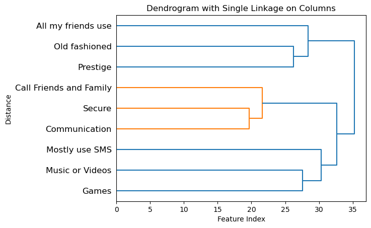

```python
from scipy.cluster.hierarchy import linkage, dendrogram

# Assuming 'data_HS_Factor' is your data matrix
# Transpose the data matrix to cluster on columns
data_transposed = data_Usage_Factor_Final.T

# Perform hierarchical clustering with single linkage
linkage_matrix = linkage(data_transposed, method='single')

# Create a dendrogram
#dendrogram(linkage_matrix, orientation='top', labels=data_HS_Factor.columns, distance_sort='descending', show_leaf_counts=True)

# Create a dendrogram with transposed orientation
dendrogram(linkage_matrix, orientation='right', labels=data_Usage_Factor_Final.columns
           , distance_sort='descending', show_leaf_counts=True)

# Add labels and title
plt.xlabel('Feature Index')
plt.ylabel('Distance')
plt.title('Dendrogram with Single Linkage on Columns')

# Show the plot
plt.show()
```

**From the Dendrogram, it is clearly evident that there are three groups of variables, signifying different aspects. This suggest that there are correlations between variables as well as the number of factors that can be extracted.**

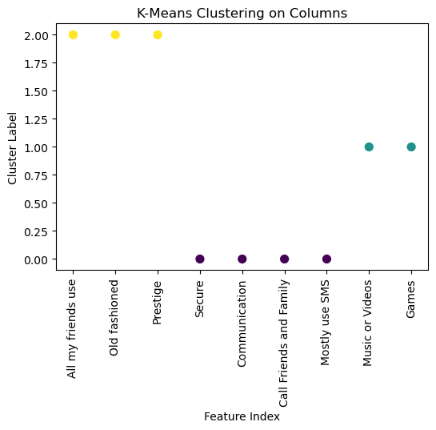

```python
import matplotlib.pyplot as plt
from sklearn.cluster import KMeans

# Assuming 'data_HS_Factor' is your data matrix
# Transpose the data matrix to cluster on columns
data_transposed = data_Usage_Factor_Final.T

# Specify the number of clusters (k)
num_clusters = 3  # You can adjust this based on your requirements

# Perform k-means clustering
kmeans = KMeans(n_clusters=num_clusters, random_state=42)
cluster_labels = kmeans.fit_predict(data_transposed)

# Visualize the results
plt.figure(figsize=(6, 4))
plt.scatter(data_transposed.index, cluster_labels, c=cluster_labels, cmap='viridis', marker='o', s=50)
plt.title('K-Means Clustering on Columns')
plt.xticks(rotation=90)
plt.xlabel('Feature Index')
plt.ylabel('Cluster Label')
plt.show()
```

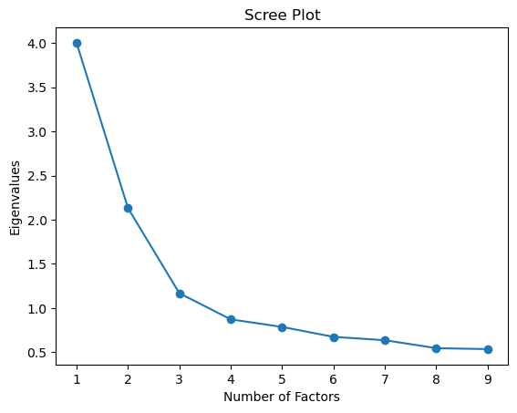

```python
import matplotlib.pyplot as plt
import numpy as np
from factor_analyzer import FactorAnalyzer

# Assuming 'data_HS_Factor' is your DataFrame
# Specify a range of factor numbers
num_factors_range = range(1, len(data_Usage_Factor_Final.columns) + 1)

# Create an empty list to store eigenvalues
eigenvalues = []

# Iterate over different numbers of factors
for n_factors in num_factors_range:
    fa = FactorAnalyzer(n_factors, method='principal', rotation='varimax')
    fa.fit(data_Usage_Factor)
    eigenvalues.append(fa.get_eigenvalues()[0][n_factors - 1])  # Extract the eigenvalue for the specified number of factors

# Plot the scree plot
plt.plot(num_factors_range, eigenvalues, marker='o')
plt.title('Scree Plot')
plt.xlabel('Number of Factors')
plt.ylabel('Eigenvalues')
plt.show()
```

### 4.1.2 Communalities

The Communalities Table shows that all the variables have their communalities above 0.5 and the maximum communality value is 0.720. We also note that most of the values are above 0.6. From this we can say that the extracted factors explains more than 60 % of variation in majority of the variables.

```python
import pandas as pd
from factor_analyzer import FactorAnalyzer

# Assuming 'data_HS_Factor' is your DataFrame
# Specify the number of factors
n_factors = 3

#The rotation must be one of the following:
#['varimax', 'oblimax', 'quartimax', 'equamax', 'geomin_ort', 'promax', 'oblimin', 'quartimin', 'geomin_obl', None]
# Defaults to ‘promax’.

# Create a FactorAnalyzer object
fa_woer = FactorAnalyzer(len(data_Usage_Factor_Final.columns),method='principal',rotation=None) #without extracation and rotation
fa_wer  = FactorAnalyzer(n_factors,method='principal', rotation='varimax')

# Fit the factor model to your data
fa_woer.fit(data_Usage_Factor_Final)
fa_wer.fit(data_Usage_Factor_Final)

# Get the variable names
features = data_Usage_Factor_Final.columns

# Get initial communalities
communalities_without_extraction_rotation = fa_woer.get_communalities()

# Get extracted communalities
communalities_with_extraction_rotation = fa_wer.get_communalities()

# Create a DataFrame with feature, initial communality, and extracted communality
communalities_table = pd.DataFrame({    'Feature': features,
                                    'Communalities (Initial)': communalities_without_extraction_rotation,
                                    'Communalities (With Extraction and Rotation)': communalities_with_extraction_rotation,
                                   })

# Display the communalities table
# print('\n',features)
# print('\n',communalities_without_rotation)
# print('\n',communalities_with_rotation,'\n')

communalities_table.style.applymap(highlight_cell)
```

|  | Feature | Communalities (Initial) | Communalities (With Extraction and Rotation) |
| --- | --- | --- | --- |
| 0 | All my friends use | 1.000000 | 0.670556 |
| 1 | Old fashioned | 1.000000 | 0.686274 |
| 2 | Prestige | 1.000000 | 0.644226 |
| 3 | Secure | 1.000000 | 0.604510 |
| 4 | Communication | 1.000000 | 0.664007 |
| 5 | Call Friends and Family | 1.000000 | 0.541632 |
| 6 | Mostly use SMS | 1.000000 | 0.503677 |
| 7 | Music or Videos | 1.000000 | 0.719980 |
| 8 | Games | 1.000000 | 0.664838 |

### 4.1.3 Total Variance Explained

Consider the Total Variance Explained Table. From the table it can be seen that there are three factors extracted and the three factors explains 63.330 % total variation. The first factor explains 29.288 % of variation. The second factor explains 21.132% of variation and the third factor explains 12.909 % of variation.

```python
import pandas as pd
from factor_analyzer import FactorAnalyzer

# Assuming 'data_HS_Factor' is your DataFrame
# Specify the number of factors
n_factors = 3

# Create a FactorAnalyzer object
fa = FactorAnalyzer(n_factors, method='principal', rotation='varimax')

# Fit the factor model to your data
fa.fit(data_Usage_Factor_Final)

# Get the explained variance
explained_variance = fa.get_factor_variance()

# Get additional information
initial_eigenvalues = fa.get_eigenvalues()[0]
percentage_of_variance = initial_eigenvalues / sum(initial_eigenvalues) * 100
cumulative_percentage_of_variance = percentage_of_variance.cumsum()

rotation_sums_squared_loadings = fa.get_factor_variance()[0]
percentage_of_rotation_sums_squared_loadings = fa.get_factor_variance()[1]*100
cumulative_percentage_of_rotation_sums_squared_loadings = fa.get_factor_variance()[2]*100

intial_variance_table = pd.DataFrame({
    'Component': [f'{i + 1}' for i in range(len(data_Usage_Factor_Final.columns))],
    'Initial Eigenvalues': initial_eigenvalues,
    'Initial Eigenvalues (% of Variance)': percentage_of_variance,
    'Initial Eigenvalues (%Cumulative of Variance)': cumulative_percentage_of_variance,

})

factor_variance_table = pd.DataFrame({
    'Component': [f'{i + 1}' for i in range(n_factors)],
    'Rotation SS Loadings': rotation_sums_squared_loadings,
    'Rotation SS Loadings (% of Variance)': percentage_of_rotation_sums_squared_loadings,
    'Rotation SS Loadings (Cumulative of Variance)': cumulative_percentage_of_rotation_sums_squared_loadings
})

# Combine both dataframes
combined_table = pd.merge(intial_variance_table, factor_variance_table, on='Component', how='left')

# Display the combined table
print("Total Variance Explained Table:")
round(combined_table,3)
```

```
Total Variance Explained Table:
```

|  | Component | Initial Eigenvalues | Initial Eigenvalues (% of Variance) | Initial Eigenvalues (%Cumulative of Variance) | Rotation SS Loadings | Rotation SS Loadings (% of Variance) | Rotation SS Loadings (Cumulative of Variance) |
| --- | --- | --- | --- | --- | --- | --- | --- |
| 0 | 1 | 2.636 | 29.288 | 29.288 | 1.926 | 21.400 | 21.400 |
| 1 | 2 | 1.902 | 21.132 | 50.421 | 1.796 | 19.957 | 41.356 |
| 2 | 3 | 1.162 | 12.909 | 63.330 | 1.978 | 21.974 | 63.330 |
| 3 | 4 | 0.669 | 7.431 | 70.761 | NaN | NaN | NaN |
| 4 | 5 | 0.655 | 7.278 | 78.039 | NaN | NaN | NaN |
| 5 | 6 | 0.578 | 6.424 | 84.463 | NaN | NaN | NaN |
| 6 | 7 | 0.502 | 5.577 | 90.040 | NaN | NaN | NaN |
| 7 | 8 | 0.465 | 5.171 | 95.211 | NaN | NaN | NaN |
| 8 | 9 | 0.431 | 4.789 | 100.000 | NaN | NaN | NaN |

### 4.1.4 Component Matrix

From the Unrotated Factor Solution we can observe that 6 variables are loaded on the first factor and three variables are loaded on the second factor. And the third factor does not have a better loadings to the variables than the other two factors. Then it is difficult to make an interpretation of the factors. To make it easy we rotate the factors using varimax rotation.

```python
import pandas as pd
from factor_analyzer import FactorAnalyzer

# Assuming 'data_HS_Factor' is your DataFrame
# Specify the number of factors
n_factors = 3

# Create a FactorAnalyzer object
fa = FactorAnalyzer(n_factors,method='principal', rotation=None)

# Fit the factor model to your data
fa.fit(data_Usage_Factor_Final)

# Get the component matrix
component_matrix = pd.DataFrame(fa.loadings_, index=data_Usage_Factor_Final.columns
                                , columns=[f'Factor {i + 1}' for i in range(n_factors)])

# Display the component matrix
print("Component Matrix:")
component_matrix.style.applymap(highlight_cell)
```

```
Component Matrix:
```

| Feature | Factor 1 | Factor 2 | Factor 3 |
| --- | --- | --- | --- |
| All my friends use | 0.537597 | -0.496864 | 0.366977 |
| Old fashioned | 0.554361 | -0.489050 | 0.373882 |
| Prestige | 0.611817 | -0.483032 | 0.191274 |
| Secure | 0.363905 | 0.608528 | 0.319025 |
| Communication | 0.242821 | 0.670603 | 0.394128 |
| Call Friends and Family | 0.400629 | 0.569667 | 0.237922 |
| Mostly use SMS | 0.630501 | 0.127568 | -0.299786 |
| Music or Videos | 0.696094 | 0.113261 | -0.471810 |
| Games | 0.656758 | 0.094357 | -0.473924 |

### 4.1.5 Rotated Factor Solution

```python
import pandas as pd
from factor_analyzer import FactorAnalyzer

# Assuming 'data_HS_Factor' is your DataFrame
# Specify the number of factors
n_factors = 3

# Create a FactorAnalyzer object
fa = FactorAnalyzer(n_factors, method='principal', rotation='varimax')

# Fit the factor model to your data
fa.fit(data_Usage_Factor_Final)

# Get the component matrix
component_matrix = pd.DataFrame(fa.loadings_, index=data_Usage_Factor_Final.columns
                                , columns=[f'Factor {i + 1}' for i in range(n_factors)])

# Display the component matrix
print("Rotated Component Matrix:")
component_matrix.style.applymap(highlight_cell)
```

```
Rotated Component Matrix:
```

| Feature | Factor 1 | Factor 2 | Factor 3 |
| --- | --- | --- | --- |
| All my friends use | 0.066050 | -0.004167 | 0.816196 |
| Old fashioned | 0.074297 | 0.011462 | 0.824998 |
| Prestige | 0.241698 | -0.058092 | 0.763173 |
| Secure | 0.120439 | 0.768087 | 0.006860 |
| Communication | -0.009493 | 0.812119 | -0.066175 |
| Call Friends and Family | 0.197324 | 0.708913 | 0.011717 |
| Mostly use SMS | 0.673090 | 0.168395 | 0.149230 |
| Music or Videos | 0.836347 | 0.091437 | 0.110194 |
| Games | 0.807231 | 0.061627 | 0.097046 |

From the above discussion we note that the factors are clearly defined. we note that the variables

- Old fashioned (0.825)
- All my friends use (0.816)
- Prestige (0.763)

- Music or Videos (0.836)
- Games (0.807)
- Mostly use SMS (0.673) These variables can form a meaningful factor.

- Communication (0.812)
- Secure (0.768)
- Call Friends and Family (0.709) These variables can also grouped into a single factor.

### 4.1.6 Conclusion

We may conclude that the students are mainly using a mobile for **show-off** and **entertainment** rather than **communication.**